# Améliorer le NNUE de Yolah

Ce que fait le réseau aujourd’hui, ce qui le limite, et les transformations proposées

Date de publication

29 octobre 2026

# 1 Où en est-on

La recherche du joueur minimax a été améliorée pas à pas, toujours avec le même réseau (`nnue_193x1024x64x32x1_distill`, int8). Mesuré contre l’étalon figé (la recherche de `MinMaxNNUE_QuantizedPlayer` sur un thread), le joueur dev gagne :

| Cadence | 0,2 s | 1 s | 3 s |
| --- | --- | --- | --- |
| dev contre étalon (campagne Y7, 2000 / 2000 / 1000 parties) | +280 | +295 | +308 |

Les derniers réglages de la recherche (proxy cut, MPC, ordre des coups, LMR, élagages) sont sur un plateau : les variantes testées restent à ±5 Elo les unes des autres. Deux mesures disent où se trouve la marge suivante :

- **le réseau coûte cher** : `NNUE_Quantized::value()` représente à lui seul environ 51 % des instructions exécutées pendant la recherche (profil callgrind) ; la logique de la recherche, moins de 3 % ;
- **le réseau est loin de son maître** : dans le tournoi de classement (2 s/coup, avant le travail sur la recherche), le joueur MCTS avec le ResNet était environ 400 Elo au-dessus du meilleur minimax NNUE. La recherche en a rattrapé une partie ; l’écart restant est à remesurer, mais il vient de l’évaluation.

L’étape suivante est donc l’évaluation. Ce document décrit le réseau actuel en partant du code, puis cinq transformations, de la moins coûteuse à la plus coûteuse, avec à chaque fois ce qui change dans le code.

# 2 Le NNUE d’aujourd’hui

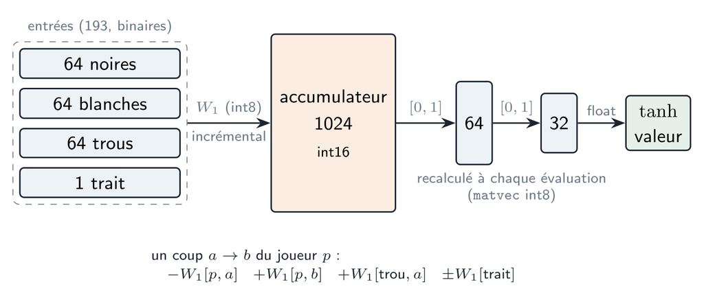

Figure 1: Le réseau actuel : 193 entrées binaires, un accumulateur de 1024 neurones mis à jour à chaque coup, puis trois petites couches recalculées à chaque évaluation.

## 2.1 Les entrées

La position est codée en 193 bits : trois plans de 64 cases (pièces noires, pièces blanches, trous) et un bit pour le joueur au trait. C’est `preprocess_nnue.py` qui fabrique le cache d’entraînement :

```python
# nnue/preprocess_nnue.py
inputs[cursor, 0:64]    = bb_to_bits(y.black)      # pièces noires
inputs[cursor, 64:128]  = bb_to_bits(y.white)      # pièces blanches
inputs[cursor, 128:192] = bb_to_bits(y.empty)      # trous (cases déjà jouées)
inputs[cursor, 192]     = 0 if black_to_move else 1
values[cursor] = z_black if black_to_move else -z_black   # résultat, pour le joueur au trait
```

## 2.2 Le réseau

Quatre couches linéaires. Les trois premières utilisent une activation « ReLU écrêtée » à $[0,1]$ et des poids bornés à $\pm 127/64$, pour pouvoir être quantifiées en int8. La dernière, la tête de valeur, reste libre et passe par une tanh :

```python
# nnue/nnue193x1024x64x32x1.py
def forward(self, x):
    x = self.fc1(x);  x = torch.clamp(x, min=0.0, max=1.0)   # accumulateur (1024)
    x = self.fc2(x);  x = torch.clamp(x, min=0.0, max=1.0)   # 64
    x = self.fc3(x);  x = torch.clamp(x, min=0.0, max=1.0)   # 32
    return torch.tanh(self.fc4(x)).squeeze(-1)               # valeur dans (-1, 1)
```

## 2.3 L’inférence en C++ : la mise à jour incrémentale

Tout l’intérêt d’un NNUE est dans la première couche. Un coup de Yolah ne touche que trois entrées : la pièce quitte la case $a$, arrive sur la case $b$, et $a$ devient un trou. On ne recalcule donc pas le produit $W_1 x$ : on ajoute ou retranche trois lignes de $W_1$ (et celle du trait) aux 1024 sommes de l’accumulateur :

```cpp
// nnue/nnue_quantized.cpp — NNUE_Quantized::play
int pos = (player == Yolah::BLACK) ? 0 : 64;            // plan des pièces du joueur
int from_offset  = (pos + from) * H1_SIZE;
int to_offset    = (pos + to)   * H1_SIZE;
int empty_offset = (128 + from) * H1_SIZE;              // la case quittée devient un trou
for (int j = 0; j < H1_SIZE; j++)
    a.acc[j] += -input_to_h1[from_offset + j] + input_to_h1[to_offset + j] + input_to_h1[empty_offset + j];
```

Le reste du réseau (1024 → 64 → 32 → 1) est recalculé à chaque évaluation. C’est là que part le temps :

```cpp
// nnue/nnue_quantized.cpp — NNUE_Quantized::value (réseau de valeur)
for (int i = 0; i < H1_SIZE; i++) h1[i] = clamp(a.acc[i], 0, FACTOR);   // ReLU écrêtée, int8
matvec<64, 1024>(h1_to_h2, h1, h2, h2_bias);                           // 64 Ki multiplications
matvec<32, 64>(h2_to_h3, h2, h3, h3_bias);
float s = 0;
for (int i = 0; i < H3_SIZE; i++) s += value_weight[i] * h3[i];        // tête en float
return std::tanh(s / FACTOR + value_bias);
```

La recherche multiplie ensuite cette valeur par `WIN` = 30000 pour obtenir un entier (`MinMaxNNUE_DevPlayer::raw_network_value`).

## 2.4 L’entraînement : distillation du ResNet

Le réseau est entraîné par distillation (`distill_common.py`). Le maître est le ResNet valeur/politique du joueur MCTS. Pour chaque position d’une partie, la perte mélange la valeur du maître $v_t$ et le résultat de la partie $z$ :

$$L = \alpha\,\mathrm{MSE}(v_s, v_t) + (1-\alpha)\,\mathrm{MSE}(v_s, z), \qquad \alpha = 0{,}8 .$$

# 3 Ce qui limite le réseau actuel

**Chaque motif est appris deux fois.** Les entrées disent « noir / blanc » plus un bit de trait. Or la position de départ est symétrique : le miroir a$\leftrightarrow$h envoie exactement les pièces noires (a1, h8, d5, e4) sur les pièces blanches (h1, a8, e5, d4). « Ma pièce enfermée dans un coin » doit donc être appris une fois pour Noir et une fois pour Blanc, et le bit de trait, qui n’agit qu’en ajoutant une seule ligne à l’accumulateur, peut difficilement retourner le sens de tout le reste.

**Une seule tête pour toute la partie.** En début de partie, tout le plateau est connecté. Vers 24 cases libres apparaissent des territoires privés, et en dessous de 15 le plateau est découpé en régions séparées. Ce sont presque des jeux différents, et les 64 + 32 neurones doivent tous les couvrir.

**La cible est grossière.** Le résultat $z \in \{-1, 0, 1\}$ est un seul tirage d’une variable aléatoire, et la tanh comprime les positions nettement gagnantes vers $\pm 1$. Or la recherche a besoin de nuances. L’étude M (arrondir la valeur du réseau à un multiple de $G$) a montré qu’il faut au moins 60 à 120 niveaux distincts :

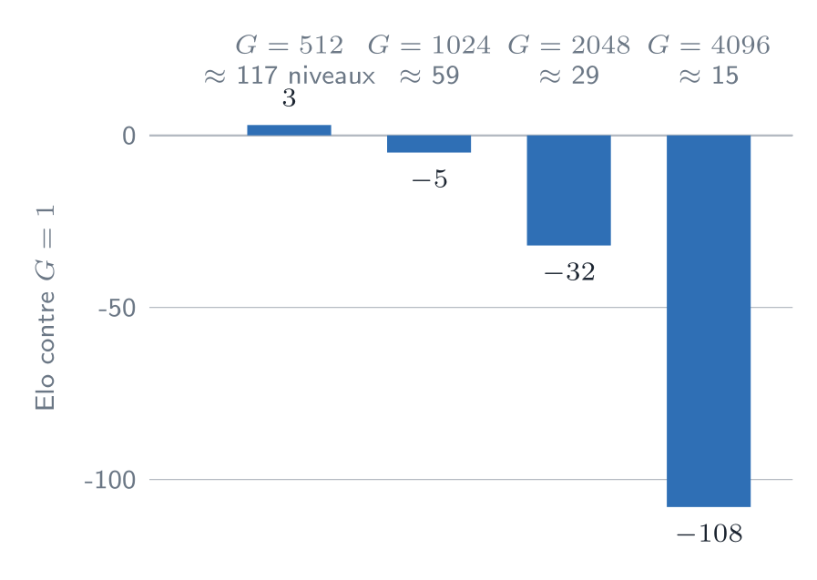

Figure 2: Elo du dev quand la valeur du réseau est arrondie à un multiple de $G$ (valeurs entre −30000 et +30000) : en dessous d’une soixantaine de niveaux, la force s’effondre ; à G = 2048, la recherche fait pourtant 34 % de nœuds en moins.

**Les données ne ressemblent pas aux positions évaluées.** Le réseau apprend sur des positions de parties, c’est-à-dire des positions où les deux joueurs ont joué de bons coups. La recherche, elle, évalue surtout des positions issues de mauvais coups (les lignes réfutées des arbres alpha-bêta), qu’il n’a presque jamais vues.

**Il ne voit que des cases, pas des structures.** Mobilité, territoire et régions sont des propriétés globales qu’un réseau à une couche cachée large reconstruit mal. L’étude J l’a montré à sa façon : l’influence (le Voronoi en pas de roi) prédit 4 à 6 fois mieux que le hasard le coup du ResNet. La recherche la calcule déjà pour ordonner les coups.

Les mesures de fin de partie le confirment (positions du cache résolues exactement par `endgame_solver`, outil `endgame_truth`). On compte les **erreurs de résultat** : la valeur annonce une victoire, une défaite ou une partie nulle, et le solveur dit autre chose.

| cases libres | maître | NNUE | issue de la partie |
| --- | --- | --- | --- |
| 10 | 0,4 % | 8,0 % | 0 % |
| 14 | 1,8 % | 9,5 % | 0 % |
| 18 | 5,3 % | 12,9 % | 0,1 % |
| 22 | 14,4 % | 18,3 % | 0,1 % |
| 24 | 16,1 % | 16,1 % | 1,2 % |
| 26 | 11,9 % | 15,8 % | 2,5 % |

Entre 10 et 14 cases libres, le maître ne se trompe presque jamais, mais le NNUE se trompe une fois sur dix. Ce n’est donc pas la cible qui manque : le réseau n’arrive pas à reproduire ce qu’on lui montre. Or ce sont justement des positions de régions : la moitié des plateaux à 12–15 cases libres sont entièrement séparés (outil `private_moves`). Deux autres essais vont dans le même sens. Une simple combinaison linéaire des caractéristiques de territoire de `heuristic_features`, ajustée phase par phase, fait mieux que le réseau à 7 cases libres ou moins, et s’en rapproche entre 8 et 21 (`phase_fit.py`). À l’inverse, des tables de valeurs par case ou par ligne, qui ne voient pas la connexité, n’apprennent presque rien en fin de partie (`pattern_fit.py`).

**Au-delà de 28 cases libres, le réseau suit bien le maître.** Le solveur ne suit plus, mais on peut comparer le NNUE au maître et à l’issue de la partie (616 000 positions du cache) :

| cases libres | NNUE vs maître (mse) | erreurs de résultat vs issue : maître | NNUE |
| --- | --- | --- | --- |
| 12–15 | 0,180 | 1,2 % | 10,3 % |
| 16–19 | **0,226** | 4,6 % | 13,7 % |
| 20–23 | **0,220** | 11,2 % | 17,6 % |
| 24–27 | 0,187 | 16,7 % | 20,9 % |
| 28–31 | 0,149 | 20,6 % | 23,0 % |
| 32–35 | 0,102 | 23,2 % | 24,7 % |
| 36–39 | 0,062 | 24,3 % | 24,6 % |
| 40–43 | 0,035 | 23,4 % | 23,9 % |
| 44–47 | 0,021 | 21,4 % | 22,2 % |
| 48–55 | 0,003 à 0,010 | ~20 % | ~21 % |

L’écart entre le réseau et son maître culmine entre 16 et 23 cases libres, puis se referme : en ouverture, le réseau reproduit presque exactement le maître. Loin de la fin, les 20 à 25 % d’erreurs contre l’issue ne sont pas vraiment des erreurs : la partie n’est pas encore décidée, et elle n’est pas jouée parfaitement. À partir de 36 cases libres, le NNUE fait jeu égal avec le maître. En milieu de partie, la limite est donc le maître (ou les positions d’entraînement), pas le réseau.

**Jusqu’où la recherche voit.** Chaque coup remplit exactement une case libre : la recherche voit la fin de la partie dès que sa profondeur atteint le nombre de cases libres. Mesuré avec `search_bench` (joueur dev, produit creux, un cœur de i7-12700K, 209 positions) :

| cases libres | profondeur médiane, 0,2 s | voit la fin | profondeur médiane, 1 s | voit la fin |
| --- | --- | --- | --- | --- |
| 0–23 | jusqu’au bout | 100 % | jusqu’au bout | 100 % |
| 24–27 | 21 | 8 % | 24 | 16 % |
| 32–35 | 19 | 0 % | 22 | 0 % |
| 36–39 | 18 | 0 % | 22 | 0 % |
| 44–47 | 15 | 0 % | 19 | 0 % |
| 48–51 | 13 | 0 % | 16 | 0 % |

Ces profondeurs sont nominales : les lignes réduites (LMR, LMP, MPC, proxy cut) vont moins loin. À 23 cases libres ou moins à la racine, la recherche n’a plus besoin du réseau. Mais une recherche lancée entre 32 et 40 cases libres atteint une profondeur de 18 à 22 : ses feuilles tombent vers 12 à 25 cases libres, exactement là où le réseau se trompe le plus. **Améliorer le réseau en fin de partie améliore donc les feuilles de toutes les recherches du milieu de partie**, là où la partie se décide.

# 4 Les transformations proposées

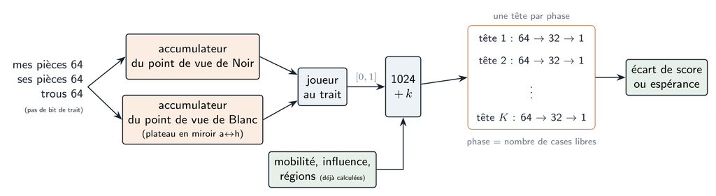

Figure 3: Le réseau proposé : deux accumulateurs (un par point de vue), quelques entrées globales ajoutées après l’accumulateur, une tête par phase de jeu, et une sortie plus fine que gagné / nul / perdu.

## 4.1 Coder du point de vue du joueur au trait

On remplace « noires / blanches / trait » par « mes pièces / ses pièces / trous », vus par le joueur au trait, avec le plateau en miroir a$\leftrightarrow$h quand c’est Blanc (le miroir qui échange exactement les positions de départ). Le bit de trait disparaît : 192 entrées.

À l’entraînement, c’est une transformation du cache :

```python
# esquisse : nouvel encodage (preprocess)
def mirror_files(bb: int) -> int:            # a<->h sur chaque rangée
    return int.from_bytes(bytes(int(f'{b:08b}'[::-1], 2) for b in bb.to_bytes(8, 'big')), 'big')

mine, theirs = (y.black, y.white) if black_to_move else (y.white, y.black)
holes = y.empty
if not black_to_move:
    mine, theirs, holes = map(mirror_files, (mine, theirs, holes))
inputs[cursor, 0:64], inputs[cursor, 64:128], inputs[cursor, 128:192] = map(bb_to_bits, (mine, theirs, holes))
```

### 4.1.1 Les entrées : trois blocs de 64

Le réseau ne connaît plus les couleurs. Ses 192 entrées, et donc les 192 lignes de la matrice de poids de la première couche, sont rangées en trois blocs :

| Lignes | Contenu |
| --- | --- |
| 0–63 | **mes pièces** : celles du propriétaire de l’accumulateur |
| 64–127 | **ses pièces** : celles de l’adversaire |
| 128–191 | les **trous** |

Une pièce sur la case `sq` active la ligne `plane + sq`, avec `plane` = 0 si elle est « à moi », 64 si elle est « à lui ». Il n’y a **qu’une seule matrice**, partagée par les deux points de vue.

### 4.1.2 Deux accumulateurs, un par couleur

Chaque accumulateur appartient à une **couleur fixe**, pas au joueur au trait :

| Accumulateur | Lignes 0–63 | Lignes 64–127 | Cases |
| --- | --- | --- | --- |
| `acc[BLACK_VIEW]` | pièces noires | pièces blanches | telles quelles : `sq` |
| `acc[WHITE_VIEW]` | pièces blanches | pièces noires | miroir a$\leftrightarrow$h : `sq ^ 7` |

Le miroir s’applique **toujours** à l’accumulateur blanc, quel que soit le joueur qui joue, et à toutes ses entrées (pièces des deux couleurs et trous). Avec `sq = 8 × rangée + colonne` (`SQ_A1` = 0, `SQ_H1` = 7), `sq ^ 7` change la colonne $c$ en $7 - c$ sans toucher à la rangée. Les blancs, qui partent de h1, a8, e5, d4, se voient ainsi partir de a1, h8, d5, e4, comme les noirs : un seul jeu de poids sert aux deux camps.

`value()` lit l’accumulateur du joueur au trait. Le réseau voit donc toujours « mes pièces dans le bloc 0, sur un plateau orienté comme pour les noirs ». Mais l’accumulateur lu change à chaque demi-coup.

### 4.1.3 Un coup met à jour les deux accumulateurs

La pièce qui bouge est « à moi » dans l’accumulateur de sa couleur et « à lui » dans l’autre. Dans chacun, on la déplace dans son bloc et on ajoute le trou :

```cpp
// esquisse : NNUE_Quantized::play avec deux points de vue
// Le point de vue noir garde les cases telles quelles ; le point de vue blanc les voit
// dans le miroir a<->h. Avec sq = 8 * rangée + colonne, sq ^ 7 change la colonne c en 7 - c.
constexpr int view_square(int v, int sq) { return v == BLACK_VIEW ? sq : sq ^ 7; }

for (int v : {BLACK_VIEW, WHITE_VIEW}) {
    const bool own = (v == BLACK_VIEW) == (player == Yolah::BLACK);  // la pièce est-elle « à moi » ?
    const int f = view_square(v, from), t = view_square(v, to);
    const int plane = own ? 0 : 64;
    sub_row(a.acc[v], plane + f);   // la pièce quitte f (dans son bloc)
    add_row(a.acc[v], plane + t);   // elle arrive en t (même bloc)
    add_row(a.acc[v], 128 + f);     // f devient un trou
}
```

Exemple, **les noirs jouent d5 → d6** :

| Accumulateur | `own` | `plane` | Cases | Mises à jour |
| --- | --- | --- | --- | --- |
| `acc[BLACK_VIEW]` | oui | 0 | d5, d6 | `sub(0 + d5)`, `add(0 + d6)`, `add(128 + d5)` |
| `acc[WHITE_VIEW]` | non | 64 | e5, e6 (miroir) | `sub(64 + e5)`, `add(64 + e6)`, `add(128 + e5)` |

Quand l’adversaire joue, notre accumulateur reçoit donc son coup dans le bloc 64.

**Pourquoi tenir les deux à jour à chaque coup.** Un accumulateur doit toujours représenter la position actuelle complète, vue depuis sa couleur. Or chacun n’est lu qu’un demi-coup sur deux :

| Instant | Trait | Accumulateur lu |
| --- | --- | --- |
| position P | noirs | `acc[BLACK_VIEW]` |
| les noirs jouent d5→d6 → P’ | blancs | `acc[WHITE_VIEW]` (le coup noir y est dans le bloc 64) |
| les blancs jouent → P’’ | noirs | `acc[BLACK_VIEW]` |

Si `acc[WHITE_VIEW]` ne recevait que les coups blancs, il évaluerait P’ sur un plateau où la pièce noire est encore en d5. Il faudrait alors le reconstruire à chaque lecture, en sommant 30 à 50 lignes (8 pièces plus les trous), au lieu de 3 lignes par accumulateur et par coup. Dans la recherche, `value()` est appelée aux profondeurs paires comme impaires, et `undo` dépile l’état du parent : les deux accumulateurs doivent être justes à chaque nœud de la pile.

### 4.1.4 La couche suivante

Deux variantes, à mesurer toutes les deux à l’étape 1 :

```cpp
// esquisse : NNUE_Quantized::value, entrée de la couche 64
const auto& us   = a.acc[side_to_move == BLACK ? BLACK_VIEW : WHITE_VIEW];
const auto& them = a.acc[side_to_move == BLACK ? WHITE_VIEW : BLACK_VIEW];
// (a) h1 = clamp(us)          → 1024 entrées, couche 64 inchangée
// (b) h1 = clamp([us, them])  → 2048 entrées (comme Stockfish)
```

- **(a) `us` seul** : `value()` ne change pas de coût. L’accumulateur de l’adversaire ne sert qu’à préparer le demi-coup suivant.
- **(b) `[us, them]`** : on concatène les deux, **toujours dans l’ordre [joueur au trait, adversaire]**. La première moitié des poids de la couche 64 s’applique toujours à l’accumulateur du joueur au trait, la seconde à celui de l’adversaire. Il n’y a rien à copier : on choisit deux pointeurs selon le trait. Le réseau voit aussi la position du point de vue adverse, mais la couche 64 double.

## 4.2 Une tête par phase de jeu

On garde le ou les accumulateurs, mais $K$ jeux de couches 1024 → 64 → 32 → 1. On choisit lequel utiliser d’après le nombre de cases libres (Stockfish fait la même chose avec le nombre de pièces, $K = 8$). À l’entraînement, on calcule toutes les têtes et on garde la bonne :

```python
# esquisse : têtes par phase (PyTorch)
class Net(nn.Module):
    def __init__(self, K=8):
        self.fc1  = nn.Linear(192, 1024)
        self.fc2  = nn.Linear(1024, 64 * K)          # les K têtes en un seul produit
        self.fc3  = nn.ModuleList(nn.Linear(64, 32) for _ in range(K))
        self.head = nn.ModuleList(nn.Linear(32, 1) for _ in range(K))

    def forward(self, x, bucket):                    # bucket = f(nombre de cases libres)
        h1 = torch.clamp(self.fc1(x), 0, 1)
        h2 = torch.clamp(self.fc2(h1).view(-1, K, 64), 0, 1)
        h2 = h2[torch.arange(len(x)), bucket]        # la tête de la phase
        ...
```

En C++, `value()` fait le même travail qu’aujourd’hui, seulement avec les matrices de la tête choisie : le coût ne change pas, la taille du fichier de poids est multipliée par environ $K$ pour les petites couches.

```cpp
// esquisse
const int free_squares = 56 - std::popcount(yolah.empty);   // 8 pièces, un trou par coup
const int k = std::min(K - 1, free_squares * K / 57);
matvec<64, 1024>(h1_to_h2[k], h1, h2, h2_bias[k]);
```

## 4.3 Des entrées globales après l’accumulateur

Mobilité, comptes d’influence, taille des régions : ces valeurs ne se mettent pas à jour incrémentalement, mais elles n’ont pas besoin d’entrer dans l’accumulateur. On les concatène à la sortie de l’accumulateur, à l’entrée de la couche 64 : quelques colonnes de plus dans une petite matrice. La recherche calcule déjà l’influence (`territory_ordering`, l’ordre des coups par territoire, +36 Elo dans l’étude J), et le cache d’évaluation évite de la recalculer.

```python
# esquisse : k entrées globales, normalisées dans [0, 1]
h1 = torch.clamp(self.fc1(x), 0, 1)
h1 = torch.cat([h1, globals_], dim=1)            # (B, 1024 + k)
h2 = torch.clamp(self.fc2(h1), 0, 1)
```

**Les régions, exactement et pour presque rien.** Une dame glisse case par case à travers des cases libres : une pièce ne pourra jamais atteindre que les composantes connexes de cases libres (en 8-connexité) qu’elle touche. Et le départ d’un coup devient un **trou**, jamais une case libre : une frontière ne se rouvre jamais. Une composante que seules mes pièces touchent est donc **privée pour toujours**. Un remplissage par bitboards (`shift_all_directions` répété) donne les composantes ; il suffit ensuite de regarder quelles pièces touchent chacune. Des entrées possibles, du point de vue du joueur au trait :

- le nombre de cases libres dans mes régions privées, dans les siennes, et dans les régions disputées ;
- le nombre de mes pièces enfermées (qui ne touchent que des régions privées), et des siennes ;
- un bit « plateau entièrement séparé » : il n’y a plus de région disputée, et le résultat ne dépend plus que du nombre de coups que chacun peut jouer dans ses territoires.

**Le calcul ne sert qu’en fin de partie.** Mesuré sur 1,85 million de positions du cache :

| cases libres | positions avec une pièce enfermée | plateau entièrement séparé |
| --- | --- | --- |
| 8–11 | 97 % | 86 % |
| 12–15 | 93 % | 55 % |
| 16–19 | 82 % | 19 % |
| 20–23 | 56 % | 3 % |
| 24–27 | 26 % | 0,2 % |
| 28–31 | 8 % | 0 |
| 32 et plus | < 2 % | 0 |

Au-dessus d’environ 28 cases libres, ces entrées valent presque toujours zéro : on peut ne pas les calculer. Elles ne coûtent donc qu’en fin de partie, là où le réseau se trompe le plus (tableau de « Ce qui limite le réseau actuel »). Elles se combinent naturellement avec les têtes par phase : la tête de fin de partie reçoit l’information dont elle a besoin.

Il reste à savoir si le gain en précision compense le coût du calcul, et seul un match le dira. Mais on sait maintenant que le défaut est réel et où il se trouve.

## 4.4 Une cible plus fine : l’écart de score

Le score de Yolah donne une cible naturellement graduée : l’écart de points entre les joueurs. Deux formes possibles :

- **régression** de l’écart final (ou de l’écart prédit par le maître), sans tanh, la valeur entière de la recherche étant directement proportionnelle à l’écart prévu ;
- **classes** d’écart (par exemple $-10\ldots+10$ et deux classes « au-delà ») avec une entropie croisée à l’entraînement, et l’espérance de l’écart utilisée en jeu. C’est l’idée « des classes pour apprendre, un scalaire pour jouer » tirée de l’étude M.

```python
# esquisse : la perte avec des classes d'écart
logits = model(x, bucket)                         # (B, C)
loss   = F.cross_entropy(logits, target_class)    # cible : classe de l'écart (du maître ou de la partie)
value  = (logits.softmax(-1) * class_centres).sum(-1)   # en jeu : l'espérance, un nombre gradué
```

**La dernière ligne, pas à pas.** Elle transforme la sortie du réseau, une liste de probabilités sur des écarts, en un seul nombre : l’écart attendu, que la recherche utilise comme évaluation.

1. **Les classes.** On découpe les écarts possibles en $C$ classes, par exemple $C = 23$ :

   ```
   classe :   0      1     2   ...   11  ...   21     22
   écart  :  ≤−11   −10   −9   ...    0  ...  +10    ≥+11
   ```

2. **`logits`**, de forme `(B, C)` : pour chacune des $B$ positions du lot, $C$ nombres bruts, un par classe ; ce ne sont pas encore des probabilités.
3. **`logits.softmax(-1)`** les transforme en probabilités (positives, de somme 1), sur la dernière dimension, celle des classes. Exemple simplifié à 5 classes :

   ```
   écarts       :  −4     −2     0     +2     +4
   probabilités :  0.05   0.10  0.20   0.40   0.25
   ```

4. **`class_centres`** : un tenseur fixe de $C$ nombres, l’écart que représente chaque classe, ici `[−4, −2, 0, +2, +4]`. Pour une classe ouverte comme « ≥ +11 », on prend une valeur typique, au mieux l’écart moyen observé dans cette classe sur les données.
5. **`* class_centres`** multiplie chaque probabilité par l’écart de sa classe ; PyTorch applique ce vecteur à chacune des $B$ lignes :

   ```
   0.05·(−4) = −0.2    0.10·(−2) = −0.2    0.20·0 = 0    0.40·(+2) = 0.8    0.25·(+4) = 1.0
   ```

6. **`.sum(-1)`** additionne sur les classes, un nombre par position, de forme `(B,)` :

   ```
   value = −0.2 − 0.2 + 0 + 0.8 + 1.0 = +1.4
   ```

   C’est l’**espérance** de l’écart : « en moyenne, je m’attends à gagner de 1,4 point ».

**Pourquoi l’espérance et pas la classe la plus probable.** La classe la plus probable (+2 ici) ne prend que 23 valeurs ; or l’étude M a montré qu’avec si peu de niveaux la recherche perd beaucoup (−108 Elo avec environ 15 niveaux, −32 avec environ 29). L’espérance varie de façon continue : deux positions dont la classe la plus probable est +2 se distinguent encore (+1,4 contre +1,9). D’où « des classes pour apprendre, un nombre pour jouer » : à l’entraînement, l’entropie croisée apprend toute la distribution (position sûre ou incertaine, gain serré ou large) ; en jeu, la recherche reçoit un nombre gradué.

**Le coût en C++.** La dernière couche passe de 32 → 1 à 32 → $C$ (23 × 32 multiplications au lieu de 32, négligeable devant les 65 536 de la couche 1024 → 64), plus $C$ exponentielles pour la softmax : quelques dizaines de nanosecondes. L’espérance est ensuite multipliée par une échelle fixe pour donner la valeur entière de la recherche (par exemple 1 point d’écart = 1000).

**En fin de partie, l’issue de la partie est une meilleure cible que le maître.** La distillation donne 80 % du poids au maître et 20 % à l’issue réelle de la partie. Or les parties du cache sont jouées parfaitement en finale : à 22 cases libres ou moins, l’issue est exacte dans 99,9 % des cas, alors que le maître se trompe dans 5 à 14 % des cas entre 18 et 22 cases libres (tableau de « Ce qui limite le réseau actuel »). Il suffit de faire dépendre ce poids de la phase de jeu : l’issue seule à 22 cases libres ou moins, le mélange actuel au-dessus. On obtient ainsi des étiquettes exactes de fin de partie sans rien résoudre. Plus tard, une remontée phase par phase pourrait étendre cette zone exacte : étiqueter les positions à 24 cases libres par une recherche courte dont les feuilles tombent dans la zone déjà fiable, réentraîner, puis passer à 28 cases libres, et ainsi de suite.

Le maître actuel ne prédit qu’une valeur dans $(-1, 1)$. Un script d’entraînement de ResNet avec l’écart de score existe déjà (`nnue/cnn_resnet_with_diff_score.py`) : c’est le point de départ naturel pour un maître qui prédit l’écart.

## 4.5 Apprendre sur les positions que la recherche évalue

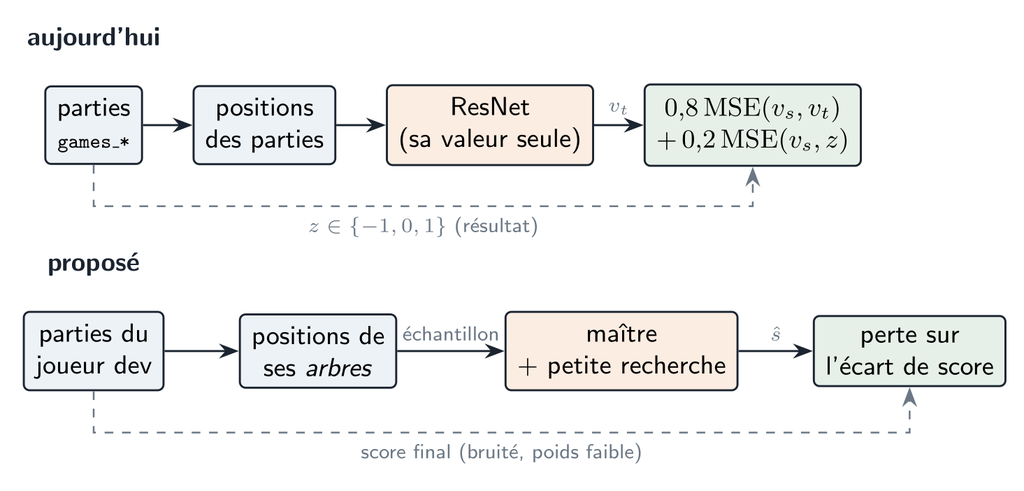

Figure 4: Le circuit des données, aujourd’hui et proposé.

On fait jouer le joueur dev, et pendant ses recherches on tire au hasard des positions **évaluées** (feuilles et nœuds internes, y compris les lignes réfutées). Le maître les étiquette, sur le cluster, à environ $10^9$ positions par jour sur une RTX 3080. On peut améliorer l’étiquette en la faisant précéder d’une petite recherche (quelques centaines de visites MCTS), plus coûteuse mais plus juste que le réseau seul. Cette transformation demande le plus de travail et de calcul, et c’est probablement elle qui rapporte le plus.

## 4.6 Taille et vitesse

`value()` représente à elle seule environ 51 % des instructions du joueur. Un réseau plus petit ou plus rapide peut donc battre un réseau plus juste : chaque nanoseconde gagnée par évaluation se transforme en nœuds, donc en profondeur. Cette section regarde où part le temps aujourd’hui, puis ce qu’on peut changer.

### 4.6.1 Où part le temps aujourd’hui

`value()` écrête l’accumulateur en int8 sur $[0, 64]$, puis enchaîne deux produits matrice–vecteur AVX2 et un petit produit scalaire en float :

```cpp
// nnue/nnue_quantized.cpp : NNUE_Quantized::value (sortie scalaire)
for (int i = 0; i < H1_SIZE; i++) {
    const int16_t v = a.acc[i];
    h1[i] = v <= 0 ? 0 : (v >= FACTOR ? FACTOR : v);        // FACTOR = 64
}
matvec<64, 1024>(h1_to_h2, h1, h2, h2_bias);                  // 65 536 multiplications
matvec<32, 64>(h2_to_h3, h2, h3, h3_bias);                    //  2 048
for (int i = 0; i < H3_SIZE; i++) s += value_weight[i] * h3[i];  // 32
return std::tanh(s / FACTOR + value_bias);
```

Le produit de `matvec` est `_mm256_maddubs_epi16` suivi de `_mm256_madd_epi16`, ou une seule instruction `_mm256_dpbusd_epi32` quand VNNI est disponible (`USE_VNNI`). Le décompte par évaluation :

| Étape | Travail | Octets de poids lus | Part des multiplications |
| --- | --- | --- | --- |
| écrêtage de l’accumulateur | 1024 int16 → int8 | 2 Ko (l’accumulateur) | — |
| `h1_to_h2` (1024 → 64) | 65 536 mult. int8 | **64 Ko** | **97 %** |
| `h2_to_h3` (64 → 32) | 2 048 mult. int8 | 2 Ko | 3 % |
| tête (32 → 1) | 32 mult. float + `tanh` | 128 o | ≈ 0 |

Et pour `play()`, à chaque coup : 3 lignes de `input_to_h1` (départ, arrivée, trou) plus la ligne du trait, soit 4 lignes de 1024 int8 ajoutées à l’accumulateur int16. Avec le point de vue du joueur au trait, la ligne du trait disparaît, mais il y a deux accumulateurs : 6 lignes au lieu de 4.

**La couche 1024 → 64 est donc presque tout le coût.** Toutes les pistes ci-dessous la visent.

### 4.6.2 La taille de l’accumulateur

Le coût de `h1_to_h2` et celui de `play()` sont proportionnels à la taille $H_1$ de l’accumulateur :

| $H_1$ | Mult. `h1_to_h2` | Poids `h1_to_h2` | Octets lus par `play()` (2 points de vue) |
| --- | --- | --- | --- |
| 512 | 32 768 | 32 Ko (tient dans le L1) | 6 Ko |
| 1024 (aujourd’hui) | 65 536 | 64 Ko | 12 Ko |
| 2048 | 131 072 | 128 Ko | 24 Ko |

À 512, `h1_to_h2` tient dans le cache L1 (32 à 48 Ko) : le gain peut dépasser le facteur 2 du nombre de multiplications. À 2048, il faut que la précision gagnée compense une évaluation près de deux fois plus lente. Seule une mesure en jeu tranche, et elle ne vaut que **une fois le point de vue et les têtes en place**, parce que ces deux changements modifient ce que le réseau arrive à apprendre à taille donnée.

### 4.6.3 Sauter les zéros de l’accumulateur

**D’où viennent les zéros.** Avant la couche 1024 → 64, `value()` écrête l’accumulateur : toute valeur négative devient 0, toute valeur au-dessus de 64 devient 64. Avec le réseau actuel, mesuré sur 200 000 positions du cache d’entraînement (poids quantifiés comme en C++), **87 % des 1024 valeurs de `h1` sont nulles**. Seule une centaine de neurones est « allumée » dans une position donnée, mais pas toujours les mêmes : aucun neurone n’est éteint sur toutes les positions.

**Ce que fait `matvec` aujourd’hui.** Il calcule chaque sortie comme un produit scalaire de sa ligne de poids avec les 1024 valeurs de `h1`, zéros compris : 65 536 multiplications à chaque évaluation, dont 87 % multiplient par 0.

**L’idée : lire la matrice par colonnes.** Le même produit s’écrit aussi comme une somme de colonnes :

```
h2 = h1[0] · colonne 0  +  h1[1] · colonne 1  +  ...  +  h1[1023] · colonne 1023  +  biais
```

Chaque terme où `h1[i]` vaut 0 n’ajoute rien : on peut le sauter, et ne lire que les colonnes des valeurs non nulles. Le résultat est **exactement** le même, au bit près : ce sont des sommes d’entiers, et l’ordre des additions n’y change rien.

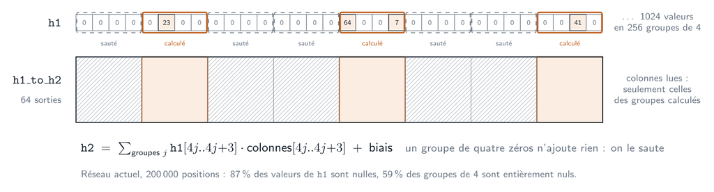

Figure 5: Le principe : `h1` est découpé en groupes de 4 valeurs ; un groupe entièrement nul est sauté, et les colonnes correspondantes de `h1_to_h2` ne sont pas lues.

**Pourquoi des groupes de 4.** L’instruction qui fait le travail, `_mm256_dpbusd_epi32` (ou `maddubs` + `madd` sans VNNI, comme dans `matvec`), multiplie **4 octets consécutifs** par 4 poids et additionne les 4 produits dans une case de 32 bits. L’unité naturelle est donc le groupe de 4 entrées : on saute un groupe quand ses 4 valeurs sont nulles, et on le calcule entièrement sinon. Sur le réseau actuel, **59 % des 256 groupes sont entièrement nuls** : il reste 41 % des multiplications, soit environ 27 000 au lieu de 65 536.

**Ranger les poids autrement.** Aujourd’hui, `h1_to_h2` est rangé par sortie : 64 lignes de 1024 octets. Pour lire « les 4 colonnes d’un groupe » d’un seul bloc, on le range par groupe d’entrées : 256 blocs de 256 octets, chaque bloc contenant, pour les 64 sorties, leurs 4 poids du groupe. C’est une simple permutation des mêmes poids, faite une fois dans `load()` : rien ne change à l’entraînement ni au fichier de poids.

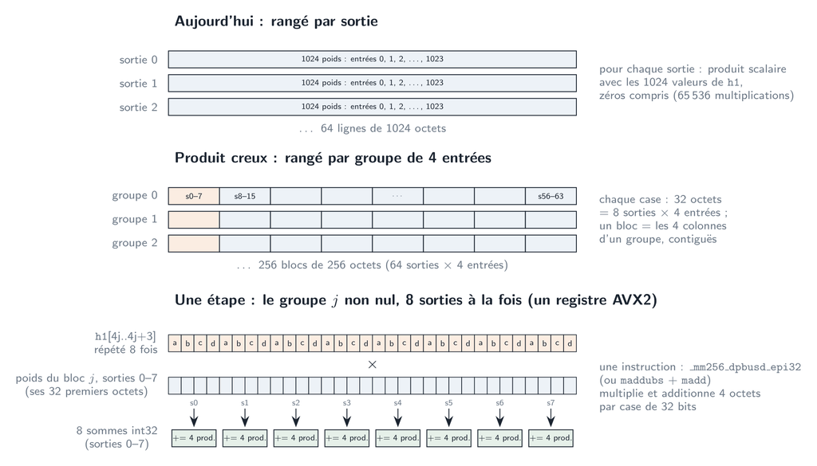

Figure 6: En haut, le rangement actuel ; au milieu, le rangement par groupe de 4 entrées ; en bas, une étape du calcul : les 4 valeurs du groupe, recopiées 8 fois dans un registre, multipliées par 32 octets de poids, ajoutent leur contribution à 8 sorties d’un coup.

Une étape traite un groupe non nul : ses 4 valeurs, recopiées 8 fois dans un registre de 32 octets, sont multipliées par les 32 premiers octets du bloc (les poids des sorties 0 à 7), ce qui ajoute leur contribution aux 8 sorties d’un coup ; 8 instructions couvrent les 64 sorties. Contrairement au calcul actuel, il n’y a pas de somme horizontale à la fin (`m256_haddx8`) : chaque case du registre est déjà une sortie.

```cpp
// esquisse : produit creux pour la couche 1024 → 64
// h1_to_h2_by_group[j * 256 + o * 32 + l * 4 + t] = poids de l'entrée 4j+t vers la sortie 8o+l
const int32_t* groups = reinterpret_cast<const int32_t*>(h1);   // 256 groupes de 4 octets

// 1. La liste des groupes non nuls (8 groupes par registre, un masque de bits, puis ses bits à 1)
//    lut[mask] = les positions des bits à 1 de mask (table de 256 × 8 entiers de 16 bits)
alignas(16) uint16_t nz[256 + 8];
int n = 0;
__m128i base = _mm_setzero_si128();
for (int j = 0; j < 256; j += 8) {
    const __m256i g = _mm256_load_si256((const __m256i*)(groups + j));
    unsigned mask = _mm256_movemask_ps(_mm256_castsi256_ps(
                        _mm256_cmpgt_epi32(g, _mm256_setzero_si256())));   // bit k : groupe j+k non nul
    _mm_storeu_si128((__m128i*)(nz + n), _mm_add_epi16(_mm_load_si128((const __m128i*)lut[mask]), base));
    n += std::popcount(mask);                                // 8 indices écrits, n avance du bon nombre
    base = _mm_add_epi16(base, _mm_set1_epi16(8));
}

// 2. La somme des colonnes des seuls groupes non nuls
__m256i sum[8];                                              // les 64 sorties, en int32
for (int o = 0; o < 8; o++) sum[o] = _mm256_setzero_si256();
for (int k = 0; k < n; k++) {
    const int j = nz[k];
    const __m256i in = _mm256_set1_epi32(groups[j]);          // les 4 valeurs, recopiées 8 fois
    const int8_t* w = h1_to_h2_by_group + j * 256;
    for (int o = 0; o < 8; o++)
        dot_accumulate(sum[o], in, _mm256_load_si256((const __m256i*)(w + 32 * o)));
}
// 3. Biais, décalage de 6 bits et écrêtage dans [0, 64], comme aujourd'hui (sans m256_haddx8)
```

(Un groupe de 4 octets dans $[0, 64]$ vu comme un entier de 32 bits est strictement positif dès qu’un des octets est non nul : la comparaison `> 0` suffit.)

Pour l’étape 1, la première version faisait une boucle sur les bits du masque (`while (mask) { nz[n++] = j + countr_zero(mask); mask &= mask - 1; }`). Le nombre de tours change à chaque registre, le processeur se trompe de branche environ une fois sur 32 octets de `h1`, et cela coûtait plus que les multiplications économisées : le produit creux était **plus lent** que le produit plein (723 ns contre 689). La table `lut`, reprise de Stockfish, écrit les 8 indices d’un coup sans aucun branchement.

**Le gain dépend de la phase de la partie.** En début de partie, le plateau est plein et beaucoup de neurones s’allument ; en fin de partie, la plupart restent éteints :

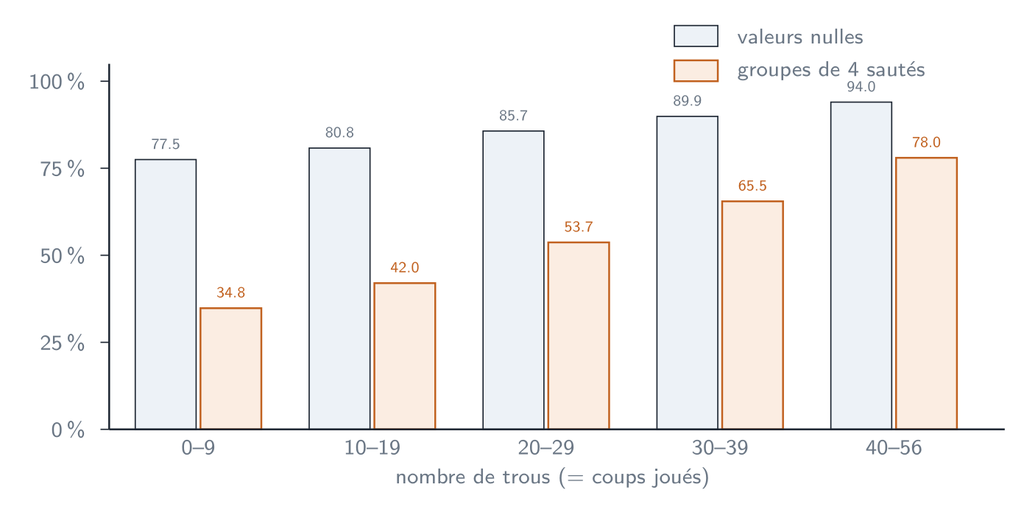

Figure 7: Proportion de valeurs nulles et de groupes de 4 entièrement nuls dans `h1`, selon le nombre de trous (réseau actuel, 200 000 positions du cache d’entraînement).

Il reste donc 65 % des multiplications en ouverture et 22 % en fin de partie. Comme la recherche passe beaucoup de temps en milieu et fin de partie, on peut espérer une couche 1024 → 64 environ deux fois plus rapide en moyenne, donc un `value()` nettement moins cher. La recherche de groupes non nuls coûte peu : 32 comparaisons de registres.

**Ce qu’il faut vérifier, et ce qui peut aider.**

- **L’exactitude** : la valeur doit être identique au bit près à celle de `matvec`. `nets_check` peut le vérifier directement.
- **Le vrai gain** : moins de multiplications, mais des accès mémoire par blocs dispersés au lieu d’une lecture continue, et une boucle de longueur variable. Seule une mesure de `value()` puis des nœuds par seconde (`search_bench`) le dira (mesures ci-dessous).
- **Regrouper les neurones qui s’allument ensemble.** Permuter les 1024 neurones (lignes de `fc1` et colonnes de `fc2` dans le même ordre) ne change pas le réseau, mais si des neurones souvent allumés ensemble se retrouvent dans les mêmes groupes, il y a plus de groupes entièrement nuls : on passe de « 87 % de valeurs nulles » vers « 87 % de groupes nuls ». Stockfish fait cette permutation à partir de statistiques sur des positions.
- **Encourager les zéros à l’entraînement** : une petite pénalité sur `h1` (L1) pousse plus de neurones à rester éteints. À doser : trop forte, elle coûte en précision.
- **Avec le produit par paires** (ci-dessous), le produit est nul dès qu’une des deux moitiés l’est : encore plus de zéros à sauter.

**Implémentation et mesures.** Le produit creux est dans `nnue/sparse_matvec.h`, utilisé par `NNUE_Quantized` (le réseau 193) et `NNUE_Persp` ; le joueur dev l’active par l’option `"sparse h1": true` (désactivé par défaut, le temps du match). Sans VNNI, deux groupes partagent un même `madd` : leurs deux `maddubs` s’ajoutent en 16 bits sans saturer, car `h1` ≤ 64 (2 × 64 × 127 × 2 = 32 512 < 32 767). Mesures sur i7-12700K, un cœur :

|  | produit plein | produit creux |  |
| --- | --- | --- | --- |
| `value()`, réseau 193 | 685 ns | 453 ns | −34 % |
| `value()`, NetPersp K = 8 (essai) | 758 ns | 515 ns | −32 % |
| `value()`, NetPersp K = 8 + THEM (essai) | 1342 ns | 931 ns | −31 % |
| `search_bench`, profondeur 9, 209 positions | 1,60 s | 1,27 s | −21 % |

`nets_check check_sparse` : 0 valeur différente sur les 83 332 positions de 3000 parties, pour les trois réseaux. `search_bench` : même arbre, même valeur et même coup sur 209/209 positions. Ce que vaut ce gain de vitesse en Elo se mesure par la campagne S1 (`dev_y7_sparse` contre `dev_y7`, 4000 parties à chaque cadence) :

| cadence | score | Elo | intervalle à 95 % |
| --- | --- | --- | --- |
| 0,2 s par coup | 58,7 % | +60,7 | [+52,8 ; +68,7] |
| 1 s par coup | 55,0 % | +34,9 | [+27,7 ; +42,3] |

Le gain baisse quand le temps augmente, comme pour tout gain de vitesse : 21 % de nœuds en plus valent moins quand la recherche est déjà profonde. Le produit creux est activé par défaut (option `sparse h1`).

### 4.6.4 Le produit par paires

Stockfish coupe l’accumulateur en deux moitiés et multiplie les deux, terme à terme, après écrêtage. La couche suivante reçoit 2 fois moins d’entrées, donc coûte 2 fois moins. Le produit apporte en plus une non-linéarité que la ReLU écrêtée seule n’a pas :

```python
# esquisse : produit par paires (PyTorch), accumulateur de 1024
h1 = torch.clamp(self.fc1(x), 0, 1)
h1 = h1[:, :512] * h1[:, 512:]          # 512 entrées pour fc2 au lieu de 1024
h2 = torch.clamp(self.fc2(h1), 0, 1)    # nn.Linear(512, 64)
```

```cpp
// esquisse : en C++, le produit de deux valeurs dans [0, 64] ramené dans [0, 64]
for (int i = 0; i < H1_SIZE / 2; i++) {
    const int x = std::clamp<int>(a.acc[i], 0, FACTOR);
    const int y = std::clamp<int>(a.acc[i + H1_SIZE / 2], 0, FACTOR);
    h1[i] = (x * y) >> 6;                  // / FACTOR
}
matvec<64, H1_SIZE / 2>(h1_to_h2, h1, h2, h2_bias);
```

Le produit retombe dans $[0, 64]$, donc la suite de `value()` ne change pas. Le produit par paires produit aussi beaucoup de zéros (il suffit qu’une des deux moitiés soit nulle), ce qui se combine bien avec le produit creux.

### 4.6.5 La SCReLU

C’est l’alternative au produit par paires : on garde toutes les entrées, mais on élève au carré la valeur écrêtée, `SCReLU(a) = clamp(a, 0, 1)²`. Elle n’allège pas la couche suivante ; elle donne plus de capacité pour le même coût. En C++, c’est le même calcul que ci-dessus avec `y = x`. Il faut choisir entre les deux par la mesure, pas les cumuler.

### 4.6.6 Pourquoi le carré ou le produit donnent plus de capacité

**Aujourd’hui, avec la CReLU.** Un neurone de l’accumulateur est une somme, où `x[...]` vaut 1 si l’entrée est active (une pièce ou un trou sur cette case), 0 sinon :

```
a = b + w[d5]·x[d5] + w[e5]·x[e5] + w[c3]·x[c3] + ...
```

Si `a` reste entre 0 et 1, la CReLU le laisse passer tel quel. Une pièce en d5 ajoute alors toujours `w[d5]` à `a`, que e5 soit un trou ou non : **l’effet de d5 ne dépend pas du reste du plateau**. La couche suivante fait elle aussi des sommes, donc tant que tous les neurones restent entre 0 et 1, le réseau entier n’est qu’une somme de contributions, une par case. Il ne peut pas dire « d5 vaut plus *si* e5 est un trou ».

La seule façon d’y arriver passe par les coupures en 0 et en 1. Exemple, avec un neurone réglé pour cela :

```
a = −1 + 0,8·x[d5] + 0,8·x[e5]

d5 seul       : a = −0,2  → CReLU → 0      (éteint)
e5 seul       : a = −0,2  → CReLU → 0      (éteint)
d5 et e5      : a = +0,6  → CReLU → 0,6    (allumé)
```

Le biais −1 tient le neurone sous 0 ; il ne s’allume que si d5 **et** e5 sont présents : c’est un « ET » obtenu par le seuil. Mais il faut un neurone entier pour cette paire, et dans une vraie position les autres cases ajoutent aussi leurs poids à `a`, ce qui déplace le seuil. Pour couvrir beaucoup de paires de cases, et de façon fiable, il faut beaucoup de neurones.

**Avec la SCReLU**, on élève au carré. Avec seulement deux entrées, pour voir ce qui se passe :

```
a  = b + p·x[d5] + q·x[e5]

a² = b²
   + 2b·p·x[d5] + 2b·q·x[e5]      ← partie additive, comme avant
   + p²·x[d5] + q²·x[e5]          ← idem (x² = x quand x vaut 0 ou 1)
   + 2·p·q · x[d5]·x[e5]          ← NOUVEAU : vaut 1 seulement si d5 ET e5 sont actifs
```

Le terme `x[d5]·x[e5]` est une **interaction entre deux cases**. Avec toutes les entrées, et pas seulement deux, le carré d’un neurone `n` contient un terme pour **chaque paire** de cases `(f, g)`, de poids `w_n[f]·w_n[g]`. Un seul neurone porte donc toutes les paires à la fois, mais leurs poids ne sont pas libres : ils sont tous fabriqués à partir des mêmes 192 nombres `w_n[·]`. Un neurone ne peut pas, par exemple, renforcer la paire (d5, e5) sans toucher aussi aux paires (d5, c3), (e5, c3), etc.

C’est la couche suivante qui donne la liberté. Une de ses sorties additionne les 1024 carrés avec ses propres poids `c[n]` ; le poids final de la paire (f, g) devient :

```
poids(f, g) = c[1]·w_1[f]·w_1[g] + c[2]·w_2[f]·w_2[g] + ... + c[1024]·w_1024[f]·w_1024[g]
```

Chaque neurone ajoute un « motif de paires » de forme imposée, et la somme de 1024 motifs pondérés peut approcher presque n’importe quel tableau de poids de paires. Il n’y a que 192 entrées, donc 192 × 192 paires, et en algèbre linéaire 192 motifs bien choisis suffisent déjà à reproduire n’importe quel tableau symétrique de cette taille. Avec 1024 neurones, le réseau peut donc, en principe, donner à chaque paire de cases le poids qu’il veut. En pratique, les mêmes poids servent aussi à la partie additive et aux coupures en 0 et 1, donc tout n’est pas libre, mais l’idée est là.

« Plus de capacité » veut donc dire :

- **autant de poids** qu’avant ;
- **presque le même coût** : 1024 multiplications de plus, contre 65 536 dans `h1_to_h2` ;
- **des fonctions plus riches** : des produits de cases, et pas seulement des sommes.

**Le produit par paires** fait la même chose en plus souple, parce qu’il multiplie deux neurones *différents* :

```
a1 = b1 + p1·x[d5] + q1·x[e5] + ...
a2 = b2 + p2·x[d5] + q2·x[e5] + ...

a1·a2 contient (p1·q2 + q1·p2) · x[d5]·x[e5]
```

Le poids de l’interaction vient de deux jeux de poids indépendants : il a plus de liberté. En plus, la couche suivante reçoit deux fois moins d’entrées.

**Les réserves.** Le gain n’est pas garanti et se mesure en jeu. En int8, `a` va de 0 à 64, donc `a²` va jusqu’à 4096 : il faut diviser par 64 (`>> 6`) pour revenir entre 0 et 64, et on perd de la précision sur les petites valeurs, là où le carré écrase déjà tout.

### 4.6.7 La place dans les caches du processeur

Une évaluation lit toute la matrice `h1_to_h2` : elle doit rester dans le cache L2. Les têtes par phase multiplient le nombre de ces matrices par $K$, mais une évaluation n’en lit qu’une. Une tête couvre environ 57 / 8 ≈ 7 demi-coups, et les feuilles d’une même recherche sont à quelques demi-coups les unes des autres : une ou deux têtes alternent pendant une recherche. Ce qui compte, c’est donc ces une ou deux matrices, selon les machines :

| Machine | L2 par cœur | 1024 → 64, 1 à 2 têtes (64–128 Ko) | `[us, them]` 2048 → 64, 1 à 2 têtes (128–256 Ko) |
| --- | --- | --- | --- |
| i7-12700K (poste) | 1,25 Mo | dans le L2 | dans le L2 |
| Xeon Silver 4214R (crn20–24) | 1 Mo | dans le L2 | dans le L2 |
| EPYC 7662 (crn12, crn13) | 512 Ko | dans le L2 | dans le L2, serré |
| Xeon E5-2650 v4 (crn01–07) | **256 Ko** | limite avec deux têtes | **déborde vers le L3** |

La table de transposition et le cache d’évaluation partagent ce L2. Le produit par paires divise ces tailles par deux et redonne de la marge partout.

### 4.6.8 Comment mesurer

1. **La vitesse d’abord.** Nœuds par seconde avec `search_bench`, à profondeur fixe sur les mêmes positions, pour chaque variante : $H_1$ = 512, 1024, 2048 ; produit par paires ou non ; $K$ = 1, 4, 8. Ces mesures se font avec des poids aléatoires, sans entraînement, sauf pour le produit creux : sa vitesse dépend de la proportion de zéros, donc des poids appris. Les faire sur votre machine **et** sur un E5-2650 v4, la machine où les caches sont les plus petits.
2. **La précision ensuite.** Erreur de validation de chaque variante entraînée, avec les mêmes données.
3. **L’Elo enfin**, en jeu à 1 s/coup, pour les deux ou trois variantes qui offrent le meilleur compromis.

Au passage, dans `nnue/nnue_quantized.h:24`, `h2_to_h3` est déclaré avec `H1_SIZE * H2_SIZE` (64 Ko) alors que seuls 64 × 32 = 2 Ko servent. Ces octets ne sont jamais lus, donc ils ne coûtent rien en cache, mais la taille est fausse et sera à corriger en même temps.

# 5 Les caractéristiques candidates

La section « Des entrées globales après l’accumulateur » posait le principe : quelques nombres calculés sur la position, ajoutés à l’entrée de la deuxième couche. Ce chapitre décrit précisément chacun des nombres candidats : l’idée de jeu qu’il traduit, sa définition exacte, un schéma, le code qui le calcule, ce que les mesures en ont dit et ce qu’il coûte. Le chapitre suivant décrit l’ablation qui choisira lesquels garder.

## 5.1 Avant de commencer : quatre points communs à toutes les caractéristiques

### 5.1.1 Où elles entrent dans le réseau

Le réseau calcule d’abord deux grands vecteurs de 1024 nombres, les accumulateurs : l’un décrit la position vue par le joueur au trait, l’autre vue par son adversaire. Ils sont mis à jour à chaque coup, sans être recalculés. Les caractéristiques de ce chapitre sont des nombres en plus, calculés directement sur la position à chaque évaluation, et ajoutés à côté des accumulateurs à l’entrée de la deuxième couche.

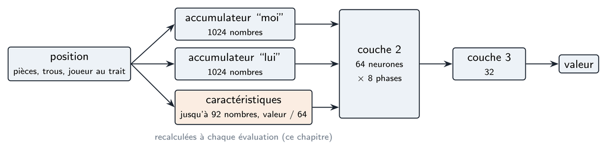

Figure 8: Les caractéristiques entrent dans la deuxième couche, à côté des deux accumulateurs. Elles ne touchent ni à la première couche ni à sa mise à jour incrémentale.

### 5.1.2 Chaque caractéristique est calculée deux fois : pour moi et pour lui

« Moi » désigne toujours le joueur **au trait** (pions noirs pleins sur les schémas), « lui » son adversaire (pions blancs), quelle que soit leur couleur. Chaque caractéristique donne donc deux colonnes : la valeur pour moi et la valeur pour lui. Par exemple, pour la mobilité : mes 38 coups légaux et ses 35.

Pourquoi ne pas donner directement la différence 38 − 35 ? Parce que les deux côtés ne pèsent pas pareil : l’étude de territoire a montré qu’une case de mobilité retirée à l’adversaire compte plus qu’une case de mobilité gagnée pour soi. Avec les deux valeurs, le réseau apprend lui-même le bon poids de chacune.

### 5.1.3 Chaque colonne est un entier de 0 à 64

Le réseau reçoit $\text{valeur}/64$, donc un nombre entre 0 et 1. Ce choix a une raison pratique : dans le réseau quantifié du C++, les entrées sont des entiers sur 8 bits à l’échelle 64, et l’entrée est alors exactement l’entier calculé. Le réseau du C++ voit donc exactement ce que le réseau a vu pendant l’entraînement, sans aucune erreur d’arrondi.

Pour que toutes les colonnes utilisent bien cette plage, deux règles :

- **les petits comptes sont multipliés.** Un nombre de pièces (0 à 4) est multiplié par 16 : 3 pièces donnent 48, que le réseau reçoit comme 0,75 ;
- **les distances sont inversées**, en $64/d$ : une distance de 1 donne 64, de 2 donne 32, de 3 donne 21, et « jamais » donne 0. Ainsi, plus c’est proche, plus le nombre est grand, et l’absence de chemin n’est pas confondue avec une distance énorme.

Les valeurs plus grandes que 64 (une mobilité de 80 en ouverture) sont ramenées à 64.

### 5.1.4 Une position et son miroir donnent les mêmes valeurs

Pour que les deux couleurs partagent les mêmes poids, le réseau voit les positions des Blancs retournées de gauche à droite (la colonne a devient la colonne h). Une caractéristique doit donc donner exactement la même valeur sur une position et sur son reflet ; sinon, le réseau recevrait deux nombres différents pour la même situation selon la couleur du joueur au trait.

**Les comptes ne posent aucun problème.** « J’atteins 23 cases en un coup de dame » reste vrai dans le reflet : on retourne le plateau, pas les distances. C’est le cas de CORR, des distances de dame, de l’influence et des sommes de l’encerclement.

**Le piège vient des listes de pièces** (connectivité, encerclement). Prenons l’encerclement. Pour chacune de mes 4 pièces, on calcule trois nombres :

- ses **libertés** : ses cases voisines libres ;
- sa **gêne** : combien de cases ses lignes de dame perdent à cause des pièces adverses ;
- son **attaque** : combien de ses libertés l’adversaire atteint en un coup de dame.

Ici, la gêne sert seulement à ranger les pièces : elle n’est pas écrite pièce par pièce (on la retrouve dans les totaux du camp, décrits avec l’encerclement, Section 5.10). Chaque pièce écrit seulement deux nombres : **8 × attaque** et **64 × fermable** (1 si elle n’a qu’une liberté et que l’adversaire peut y aller). Les pièces sont rangées de la plus encerclée à la moins encerclée : le moins de libertés d’abord, puis la plus gênée, puis la plus attaquée. Supposons qu’on s’arrête aux deux premiers critères, **libertés puis gêne** :

| pièce | libertés | gêne | attaque | écrit (8 × attaque, 64 × fermable) |
| --- | --- | --- | --- | --- |
| a1 | 1 | 3 | 1 | (8, 64) |
| h8 | 1 | 3 | 0 | (0, 0) |

**La parade : que la clé de tri contienne tout ce que la pièce écrit.** La pièce écrit son attaque et « fermable », qui se déduit des libertés et de l’attaque. Avec le troisième critère, l’attaque, la pièce attaquée passe toujours en premier, quelle que soit sa case : colonnes **(8, 64), (0, 0)** dans les deux cas. Deux pièces encore à égalité sur les trois critères ont les mêmes libertés et la même attaque : elles écrivent les mêmes deux nombres, et leur ordre, qui dépend encore de la case, n’a plus d’importance. La connectivité suit la même règle : ses 5 nombres par pièce sont tous dans sa clé de tri.

Vérification : les 92 colonnes calculées sur 500 positions et sur leurs reflets sont identiques partout.

### 5.1.5 Comment lire les mesures « ce que la caractéristique ajoute »

Chaque section donne des chiffres comme « +18,6 / +1,9 en finale 10–19 ». Ils répondent à la question : **que sait cette caractéristique que le réseau actuel ne sait pas déjà ?** Voici le calcul, étape par étape.

#### 5.1.5.1 1. Les données et les deux cibles

12 millions de positions de parties réelles (`data/games`, une position sur 20). Pour chaque position, on connaît la valeur du réseau actuel, la caractéristique, et la suite de la partie. On cherche à prédire deux **cibles**, vues du joueur au trait :

- les **points restants** : l’écart final (mes points − ses points en fin de partie) moins l’écart actuel. C’est ce que la suite de la partie va encore changer au score ;
- le **résultat** : +1 si je gagne, 0 en cas de nulle, −1 si je perds.

Le premier chiffre (« +18,6 ») porte sur les points restants, le second (« +1,9 ») sur le résultat.

#### 5.1.5.2 2. On compare des positions du même stade

Prenons une caractéristique simple : Q1, le nombre de cases libres que j’atteins en un coup de dame. En ouverture, il reste beaucoup de cases libres et Q1 vaut souvent 30 ; en finale, il en reste peu et Q1 vaut plutôt 8. Or la cible dépend aussi du stade de la partie et du joueur au trait : par exemple, si les Noirs au trait avec 45 cases libres finissent en moyenne avec +3 points, mais avec +1 seulement à 15 cases libres, alors « Q1 grand » va de pair avec « beaucoup de points restants », simplement parce que les deux signalent l’ouverture. Q1 aurait l’air de prédire la suite, sans rien savoir de la position elle-même.

Pour l’éviter, on range les positions en **groupes de semblables** : même nombre de cases libres et même couleur au trait (57 × 2 groupes : de 56 cases libres au départ, 64 cases moins les 8 pièces, à 0 en fin de partie). Dans chaque groupe, on retire à chaque nombre (la cible, la valeur du réseau, la caractéristique) sa moyenne dans le groupe :

```
groupe « 45 cases libres, Noirs au trait » : moyenne de Q1 = 30, moyenne des points restants = +3
  position P : Q1 = 34, points restants = +7   →   Q1 centré = +4, points centrés = +4
  position R : Q1 = 27, points restants = +1   →   Q1 centré = −3, points centrés = −2
```

Après ce centrage, un nombre ne dit plus « on est en ouverture » mais « cette position a plus (ou moins) de Q1 que les autres positions au même stade ». C’est le sens de « on compare des positions du même stade » : seul ce qui distingue une position de ses semblables peut encore prédire la cible.

#### 5.1.5.3 3. Deux prédictions

Deux nombres décrivent chaque position :

- **v**, la valeur que le réseau actuel donne à la position, entre −1 et +1 (par exemple +0,4 : le joueur au trait est un peu mieux) ;
- **f**, la caractéristique. La plupart en ont deux colonnes, une pour moi et une pour l’adversaire : pour le flood fill corrigé, par exemple, f₁ = 20 cases pour moi et f₂ = 14 pour lui.

Tous deux sont centrés comme à l’étape 2. On fait alors deux prédictions de la cible :

- **le réseau seul** : cible ≈ a·v + b·v² + c·v³ (pourquoi un polynôme, voir ci-dessous) ;
- **le réseau plus la caractéristique** : cible ≈ a·v + b·v² + c·v³ + d₁·f₁ + d₂·f₂, avec un coefficient par colonne de la caractéristique (2 pour le flood fill corrigé, 40 pour la connectivité).

**Pourquoi un polynôme de degré 3 et pas une droite ?** La valeur du réseau sort d’un tanh, entre −1 et +1, alors que les points restants vont de −30 à +30, et le lien entre les deux n’est pas une droite :

| valeur du réseau v | 0,0 | 0,5 | 0,9 | 0,99 |
| --- | --- | --- | --- | --- |
| points restants (ordre de grandeur) | 0 | +3 | +8 | +20 |

Près de ±1, la valeur sature : de 0,9 à 0,99, v bouge à peine mais les points beaucoup. Une droite a·v ne peut pas suivre cette courbe et se tromperait fortement sur les positions très gagnées (+9 annoncé au lieu de +20). Une caractéristique qui repère ces positions (« j’ai bien plus de territoire ») corrigerait cette erreur et paraîtrait utile, alors qu’elle n’apprend rien au réseau : il savait déjà que la position était très gagnée, c’est la droite qui lisait mal sa valeur. Le polynôme de degré 3 peut se courber et corrige cette échelle d’abord ; le gain mesuré ne compte ensuite que ce que la caractéristique sait **en plus** du réseau.

Ici, **cible** désigne l’une des deux cibles de l’étape 1, centrée elle aussi : tout le calcul est fait deux fois, une fois pour les points restants (premier chiffre) et une fois pour le résultat (second chiffre), avec des coefficients ajustés séparément. Les coefficients (a, b, c, d₁, d₂…) sont ceux qui rendent la somme des carrés des erreurs la plus petite possible (moindres carrés).

**Les moindres carrés, comment ça marche.** On cherche les coefficients β (a, b, c, d₁, d₂…) pour lesquels la somme des carrés des erreurs Σ (y − ŷ)² est la plus petite, y étant la cible et ŷ la prédiction.

*Avec un seul coefficient.* Prédisons y par d·x sur quatre positions centrées :

| x | −2 | −1 | +1 | +2 |
| --- | --- | --- | --- | --- |
| y | −3 | −1 | +2 | +2 |

En essayant : d = 1 donne les erreurs −1, 0, +1, 0, de somme des carrés 2 ; d = 1,5 donne 0, +0,5, +0,5, −1, somme 1,5 ; d = 1,3 donne −0,4, +0,3, +0,7, −0,6, somme 1,1, le minimum. Inutile de chercher à tâtons : la somme des carrés est une fonction de d,

$$S(d) = \sum_i (y_i - d\,x_i)^2$$

En développant chaque carré, (y − d·x)² = y² − 2d·xy + d²·x², puis en additionnant :

$$S(d) = \sum y_i^2 \;-\; 2d \sum x_i y_i \;+\; d^2 \sum x_i^2$$

Les trois sommes sont de simples nombres calculés sur les données : S(d) est une **parabole en d**, tournée vers le haut (Σ x² > 0). Dans l’exemple, Σ y² = 18, Σ xy = 13 et Σ x² = 10, donc S(d) = 18 − 26 d + 10 d², et l’on retrouve les essais : S(1) = 2, S(1,5) = 1,5, S(1,3) = 1,1. Le minimum d’une parabole est là où sa dérivée s’annule :

$$S'(d) = -2\sum x_i y_i + 2d \sum x_i^2 = 0 \quad\Longrightarrow\quad d = \frac{\sum x_i y_i}{\sum x_i^2}$$

soit ici −26 + 20 d = 0, d = 26 / 20 = **1,3**. C’est bien un minimum : la dérivée seconde, 2 Σ x², est positive. On peut aussi dériver sans développer, avec (u²)’ = 2u·u’ et u = y − d·x, dont la dérivée par rapport à d est −x :

$$S'(d) = -2 \sum x_i\,(y_i - d\,x_i)$$

L’annuler donne Σ x·(y − d·x) = 0 : l’erreur n’est pas corrélée avec x. C’est l’équation du cas à plusieurs coefficients, ci-dessous, écrite pour une seule colonne.

*Avec deux coefficients.* Ajoutons une seconde colonne x₂ à l’exemple, et prédisons y par a·x₁ + b·x₂ :

| x₁ | −2 | −1 | +1 | +2 |
| --- | --- | --- | --- | --- |
| x₂ | +1 | −1 | +1 | −1 |
| y | −3 | −1 | +2 | +2 |

S(a, b) = Σ (y − a·x₁ − b·x₂)² dépend maintenant de deux nombres. Au minimum, la dérivée par rapport à **chacun** est nulle. Avec la même règle qu’avant (la dérivée de y − a·x₁ − b·x₂ par rapport à a est −x₁, par rapport à b est −x₂) :

$$\frac{\partial S}{\partial a} = -2 \sum x_1\,(y - a x_1 - b x_2) = 0 \qquad
\frac{\partial S}{\partial b} = -2 \sum x_2\,(y - a x_1 - b x_2) = 0$$

En développant les sommes, cela donne deux équations à deux inconnues, dont les coefficients sont de simples sommes sur les positions :

$$\begin{aligned}
a \textstyle\sum x_1^2 &+ b \textstyle\sum x_1 x_2 = \textstyle\sum x_1 y \\
a \textstyle\sum x_1 x_2 &+ b \textstyle\sum x_2^2 = \textstyle\sum x_2 y
\end{aligned}
\qquad\text{ici :}\qquad
\begin{aligned}
10\,a - 2\,b &= 13 \\
-2\,a + 4\,b &= -2
\end{aligned}$$

La seconde donne a = 2b + 1 ; dans la première, 18 b = 3 : **b = 1/6, a = 4/3**. Les erreurs deviennent −0,5, +0,5, +0,5, −0,5, de somme des carrés **1,0**, moins que le 1,1 obtenu avec x₁ seule.

*Ce que disent ces équations.* Chacune s’écrit Σ x_j · (erreur) = 0 : au meilleur choix, l’erreur restante n’a plus aucune corrélation avec aucune colonne. Vérifions : Σ x₁·erreur = (−2)(−0,5) + (−1)(0,5) + (1)(0,5) + (2)(−0,5) = 0, et de même pour x₂. À l’inverse, avec x₁ seule (a = 1,3, b = 0), les erreurs étaient −0,4, +0,3, +0,7, −0,6, et Σ x₂·erreur = −0,4 − 0,3 + 0,7 + 0,6 = **+0,6** : l’erreur « ressemblait » encore à x₂. La dérivée par rapport à b valait donc −2 × 0,6 < 0 : augmenter b un peu faisait encore baisser S, et c’est ce qu’a fait la solution à deux coefficients. Tant qu’une colonne reste corrélée avec l’erreur, on peut faire mieux ; au minimum, plus aucune ne l’est.

*Pour n colonnes*, c’est la même chose : n équations à n inconnues, une par colonne. Rangées en tableau, les sommes Σ x_j x_k forment une matrice n × n notée XᵀX (X : une ligne par position, une colonne par entrée ; Xᵀ, sa transposée, a une ligne par colonne), et les sommes Σ x_j y forment le vecteur Xᵀy. Le système s’écrit alors en une ligne, les *équations normales* :

$$X^\top X \,\beta = X^\top y$$

Dans l’exemple, XᵀX = [[10, −2], [−2, 4]], Xᵀy = [13, −2] et β = [a, b].

*Dans les études.* Une étude a des millions de positions, mais le système ne dépend que des sommes. On parcourt donc une fois les positions de la moitié d’ajustement, et pour chacune on ajoute x_j·x_k à la case (j, k) de XᵀX et x_j·y à la case j de Xᵀy. Avec 3 colonnes pour le réseau (v, v², v³) et 40 pour la connectivité, XᵀX est un tableau de 43 × 43, quel que soit le nombre de positions, et résoudre 43 équations à 43 inconnues est instantané. Deux détails :

- **10⁻⁶ sur la diagonale.** Si deux colonnes sont presque identiques (deux distances qui valent presque toujours la même chose), le système a une infinité de solutions presque aussi bonnes : on « divise par presque zéro » et les coefficients explosent. Ajouter 10⁻⁶ à chaque case Σ x_j² départage en faveur des petits coefficients, sans changer les prédictions de façon mesurable. `piece_order_study.py` procède ainsi.
- **`numpy.linalg.lstsq`**, utilisé par les autres scripts, donne le même résultat en travaillant sur X lui-même (une décomposition plus robuste numériquement). Mais X a une ligne par position : 12 millions de lignes × 43 colonnes en nombres de 8 octets font 4 Go, plus les copies de travail. C’est ce qui a manqué de mémoire sur l’étude de l’ordre des pièces, et pourquoi elle accumule XᵀX à la place.

*Pas de constante.* Une droite a d’habitude une constante, d·x + e. Avec une constante, il y aurait une équation de plus, Σ 1 · (erreur) = 0, c’est-à-dire « l’erreur est en moyenne nulle ». Comme toutes les colonnes et la cible sont centrées (moyenne 0), cette équation est satisfaite avec e = 0 : la constante est inutile.

#### 5.1.5.4 4. Ajustement sur une moitié, mesure sur l’autre

Les positions sont rangées partie par partie. Les coefficients sont calculés sur la **première moitié**, et les erreurs mesurées sur la **seconde**, qui contient d’autres parties. Une caractéristique à 40 colonnes ne peut donc pas gagner en apprenant les données par cœur : ses 40 coefficients doivent aussi marcher sur des parties qu’ils n’ont jamais vues. (Les toutes premières mesures, sur une ou deux colonnes, ont été faites sur toutes les données ; avec si peu de coefficients et des millions de positions, l’écart est négligeable.)

#### 5.1.5.5 5. Le R² et le gain

Le **R²** est la part des variations de la cible que la prédiction explique :

$$R^2 = 1 - \frac{\text{moyenne des carrés des erreurs (cible − prédiction)}}{\text{variance de la cible}}$$

Il vaut 0 % si la prédiction n’explique rien, 100 % si elle est parfaite. Sur quatre positions, avec des points restants centrés de +4, −2, +1, −3 (variance (16 + 4 + 1 + 9) / 4 = 7,5) :

|  | prédictions | erreurs | moyenne des carrés des erreurs | R² |
| --- | --- | --- | --- | --- |
| réseau seul | +3, −1, 0, −2 | +1, −1, +1, −1 | 1 | 1 − 1 / 7,5 = 86,7 % |
| réseau + caractéristique | +3,5, −1,5, +0,5, −2,5 | +0,5, −0,5, +0,5, −0,5 | 0,25 | 1 − 0,25 / 7,5 = 96,7 % |

Le **gain** est la différence des deux R², en points de pourcentage : ici +10 points. La caractéristique a réduit l’erreur de prédiction d’une quantité qui représente 10 % des variations de la cible.

Le vrai exemple : en finale 10–19, le réseau seul explique 58,2 % des variations des points restants ; avec le flood fill corrigé en plus, 76,8 %. Le flood fill corrigé ajoute donc **+18,6 points** : une information importante que le réseau ne calcule pas lui-même.

**Une seconde base.** Les 16 premières colonnes (CORR, Q1–Q3, QFIRST, QW, LATE9 et MOB, pour moi et pour lui) sont celles de l’étape 2 : le premier lot, choisi en premier et déjà entraîné. Les caractéristiques venues ensuite (influence, connectivité, encerclement) peuvent dire en partie la même chose : l’influence et le flood fill corrigé mesurent tous deux, à leur façon, à qui appartient le territoire. Pour elles, on donne donc aussi le gain par rapport à une base plus forte, le réseau **plus ces 16 colonnes** : ce second chiffre ne compte que ce que la caractéristique apporte de vraiment nouveau.

Les phases sont définies par le nombre de cases libres : **ouverture** 40 à 56, **milieu** 20 à 39, **finale** 10 à 19, puis 0 à 9. Les chiffres viennent de `test/territory_study_main.cpp` (le calcul des quantités) et des scripts `nnue/*_study.py` (l’ajustement), avec le réseau 193 distillé.

### 5.1.6 Comment on sait que le code calcule bien ce qui est décrit

`space::compute_all` (`nnue/space_features.h`) calcule les 92 colonnes avec des bitboards : c’est rapide mais difficile à relire. `nnue/space_reference.py` refait le même calcul autrement, case par case en Python, sans aucun code commun. Sur 20 000 positions de parties réelles, les deux donnent exactement les mêmes 92 colonnes (`space_features dump`, puis `python3 space_reference.py`).

Tous les nombres des schémas de ce chapitre sont calculés par cette référence (`doc/figs/make_feature_figs.py`). Les extraits de code sont raccourcis par rapport au code réel, sans changer le calcul.

## 5.2 Deux outils communs : les blocs et les coups de dame

**Les blocs.** Un bloc est une composante connexe des cases libres par pas de roi (8 voisines). Une pièce ne pourra jamais atteindre que les blocs qui touchent sa case : une dame glisse de case libre en case libre, et la case qu’elle quitte devient un trou, qui ne se rouvre jamais. Un remplissage par décalages de bitboards trouve chaque bloc :

```cpp
// nnue/space_features.h — les blocs de cases libres
uint64_t comps[64];        // les blocs trouvés (un bitboard chacun)
int size[64], nc = 0;      // leur taille, leur nombre
for (uint64_t rest = free; rest;) {                 // rest : les cases libres pas encore rangées
    uint64_t c = rest & -rest, prev = 0;            // la première de ces cases...
    while (c != prev) { prev = c; c |= shift_all_directions(c) & free; }   // ... et tout son bloc
    comps[nc] = c;
    size[nc++] = std::popcount(c);
    rest &= ~c;                                     // ce bloc est rangé
}
```

**Les coups de dame.** `queen_levels` donne, niveau par niveau, les cases libres que des pièces atteignent en 1, 2, 3… coups de dame. Chaque niveau se calcule pour toutes les cases du niveau précédent à la fois : dans chaque direction, un *remplissage occlus* (Kogge-Stone) fait glisser l’ensemble à travers les cases libres en trois doublements (1, 2 puis 4 pas), au lieu d’avancer case par case.

**Le remplissage occlus, pas à pas.** « Remplissage » : on étend un ensemble de cases dans une direction ; « occlus » : l’extension s’arrête sur la première case non libre (trou ou pièce), comme le coup d’une dame. Le moyen simple avance d’un pas à la fois : décaler l’ensemble d’une case, garder les cases libres, recommencer ; il faut jusqu’à 7 tours sur un plateau de 8. Le remplissage de Kogge-Stone (du nom d’un additionneur de processeur qui propage ses retenues de la même façon) n’en fait que 3, en doublant la longueur du saut à chaque tour. Il manipule deux ensembles :

- `gen` : les cases déjà atteintes (au départ, les cases d’où l’on part) ;
- `pro` : les cases d’arrivée possibles pour un saut de la longueur courante, c’est-à-dire les cases libres précédées d’assez de cases libres (au tour k, un saut de 2^k cases vers une case x n’est permis que si toutes les cases traversées sont libres).

**Pourquoi trois tours suffisent : les distances en binaire.** Dans la direction D, notons s−1 la case juste avant s, s−2 celle d’avant, etc. Voici le code, ligne à ligne :

```cpp
uint64_t pro = free;                         // s libre
gen |= pro & shift<D>(gen);                  // sauts de 1
pro &= shift<D>(pro);                        // s, s−1 libres
gen |= pro & shift<D>(shift<D>(gen));        // sauts de 2
pro &= shift<D>(shift<D>(pro));              // s, s−1, s−2, s−3 libres
gen |= pro & shift<D>(shift<D>(shift<D>(shift<D>(gen))));   // sauts de 4
return shift<D>(gen) & free;                 // un pas de plus, sur une case libre
```

*Les sauts.* Après chaque ligne `gen |= …`, `gen` contient les cases atteintes à toutes les distances de 0 à 2<sup>k</sup>−1 :

| après | distances dans `gen` |
| --- | --- |
| départ | 0 |
| saut de 1 | 0, 1 |
| saut de 2 | 0, 1, 2, 3 (= {0, 1} + {0, 2}) |
| saut de 4 | 0, 1, …, 7 (= {0, …, 3} + {0, 4}) |

C’est l’écriture de la distance en binaire : 5 = 1 + 4, 6 = 2 + 4, 7 = 1 + 2 + 4. Garder la distance 0 (`gen |=` et non `gen =`) est ce qui permet 4 = 0 + 4. Sept suffit pour une ligne du plateau.

*Le filtre `pro`.* Il dit si un saut peut arriver sur s :

- au départ, `pro = free` : s est libre. C’est ce qu’il faut pour un saut de 1 vers s ;
- `pro &= shift<D>(pro)` : `shift<D>(pro)` vaut 1 en s si s−1 était dans `pro`. Le nouveau `pro` dit donc « s et s−1 libres ». C’est exactement ce qu’il faut pour un saut de 2 qui part de s−2, traverse s−1 et arrive sur s ;
- `pro &= shift<D>(shift<D>(pro))` : l’ancien `pro` en s (s, s−1 libres) et en s−2 (s−2, s−3 libres). Le nouveau `pro` dit « s, s−1, s−2, s−3 libres ». Ce sont les quatre cases d’un saut de 4 qui part de s−4.

`pro` double de longueur à chaque tour en se combinant avec lui-même décalé, comme `gen`. D’où le nom de « doublement ». Deux précisions :

- la case de départ du saut (s−2, s−4) n’a pas à être libre. Elle est dans `gen` : une pièce, ou une case déjà atteinte. `pro` ne teste que les cases traversées et la case d’arrivée ;
- le bord compte comme un obstacle. `shift<D>` efface ce qui sortirait du plateau, donc une case libre en colonne h n’est jamais la « précédente » d’une case en colonne a. Le bord coupe `pro` comme un trou.

Figure 9 le montre sur un vrai plateau, vers la droite, avec quatre de mes pièces qui partent en même temps (les rangées impaires sont des trous, pour ne garder que quatre lignes) :

- **rangée 8** : a8 et sept cases libres. Il faut les trois tours pour aller jusqu’en h8 (7 = 1 + 2 + 4) ;
- **rangée 6** : le trou en f6 arrête la pièce à e6. f6 n’a jamais de point ; après le tour 1, g6 perd le sien (un saut de 2 vers g6 traverserait f6), et après le tour 2, h6 aussi (un saut de 4 vers h6 aussi) ;
- **rangée 4** : sa pièce en f4 arrête la mienne à e4 de la même façon (une pièce n’est pas une case libre) ;
- **rangée 2** : la pièce en e2 va jusqu’au bord, h2, sans réapparaître en a3 : le décalage efface ce qui sortirait du plateau.

À chaque tour, une case reçoit une flèche si elle portait un point au panneau précédent (`pro` : arrivée permise pour cette longueur de saut) et si la case située un saut plus à gauche est déjà bleue (`gen`). Après les sauts de 1, 2 et 4, toutes les distances de 0 à 7 sont couvertes, puisque toute longueur s’écrit comme une somme de 1, 2 et 4. Le dernier pas (`shift(gen) & free`) avance d’une case et ne garde que les cases libres : on obtient les coups vers la droite, à distance 1 à 7. Les cases de départ ne restent dans le résultat que si une autre case de départ, placée avant elles, les atteint.

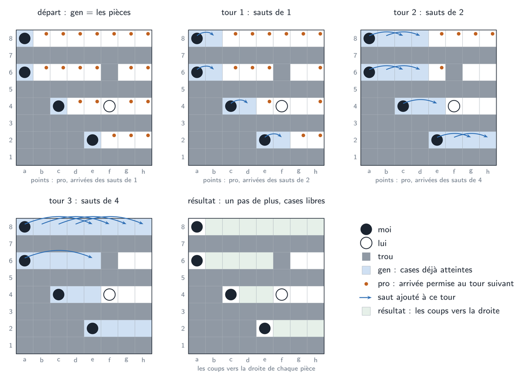

Figure 9: Le remplissage occlus vers la droite (`slide<EAST>`) sur un plateau : en bleu les cases déjà atteintes (`gen`), en points orange les arrivées permises au tour suivant (`pro`), en flèches les sauts ajoutés à chaque tour.

**À vous de jouer.** Le visualiseur ci-dessous refait le calcul pas à pas, ligne de code par ligne de code, sur la position de la figure ou sur une position que vous composez ; il calcule avec de vrais bitboards de 64 bits et les mêmes décalages que le C++.

Direction Position

gen : cases atteintes pro : arrivée permise vient de perdre son point résultat trou

Cliquez sur une case pour changer son contenu : libre → trou → ma pièce → sa pièce. Mes pièces sont les cases de départ (gen) ; les siennes, comme les trous, arrêtent les lignes. Flèches du clavier : étape précédente / suivante.

Deux avantages : il n’y a ni boucle ni test, seulement 3 tours de décalages et de ET logiques ; et `gen` peut contenir plusieurs cases de départ, qui avancent toutes en même temps, comme les quatre pièces de la figure (tout un niveau de dame d’un coup).

```cpp
// toutes les cases libres à un coup de dame de gen dans la direction D
template <Direction D> uint64_t slide(uint64_t gen, uint64_t free) {
    uint64_t pro = free;
    gen |= pro & shift<D>(gen);                         // 1 pas
    pro &= shift<D>(pro);
    gen |= pro & shift<D>(shift<D>(gen));               // 2 pas de plus
    pro &= shift<D>(shift<D>(pro));
    gen |= pro & shift<D>(shift<D>(shift<D>(shift<D>(gen))));   // 4 de plus
    return shift<D>(gen) & free;                        // la dernière case atteinte
}

// toutes les cases libres à un coup de dame de from : les 8 directions
uint64_t queen_reach(uint64_t from, uint64_t free) {
    return slide<NORTH>(from, free) | slide<SOUTH>(from, free) | slide<EAST>(from, free) |
           slide<WEST>(from, free) | slide<NORTH_EAST>(from, free) | slide<NORTH_WEST>(from, free) |
           slide<SOUTH_EAST>(from, free) | slide<SOUTH_WEST>(from, free);
}

int queen_levels(uint64_t pieces, uint64_t free, uint64_t levels[64]) {
    int n = 0;
    for (uint64_t seen = 0, front = pieces, next;
         (next = queen_reach(front, free) & ~seen); front = next) {   // un coup de plus, cases nouvelles
        levels[n++] = next;                             // les cases à n coups exactement
        seen |= next;
    }
    return n;
}
```

Le résultat a été vérifié identique à un parcours en largeur case par case avec les tables magiques, sur 1,5 million de positions. Il coûte environ 80 ns pour les deux camps et tous les niveaux.

## 5.3 Le flood fill corrigé (CORR, 2 colonnes)

**L’idée.** Le territoire qu’un camp peut encore occuper. Le flood fill classique compte toutes les cases libres des blocs que mes pièces touchent. Mais une pièce posée entre deux blocs doit **choisir** : en entrant dans l’un, elle laisse un trou derrière elle et ne pourra plus jamais atteindre l’autre (sauf si une autre de mes pièces le touche aussi).

**La définition.** Chaque pièce choisit **un** des blocs qui la touchent (ou aucun), deux pièces ne peuvent pas compter le même bloc deux fois, et CORR est le plus grand total possible de cases libres. Avec 4 pièces et quelques blocs chacune, une recherche exhaustive suffit.

**Pourquoi une pièce ne s’abstient que si elle n’a pas le choix.** La recherche n’essaie « aucun bloc » pour une pièce que lorsque tous les blocs qui la touchent sont déjà pris. Elle ne perd rien ainsi : prendre un bloc libre ne fait jamais baisser le total (un bloc a au moins une case). Dans une solution où une pièce s’abstient alors qu’un bloc libre la touche, soit ce bloc n’est pris par personne et l’ajouter augmente le total, soit une pièce suivante le prend et on peut le donner à la première sans changer le total. Le maximum est donc le même. Mais il faut garder « aucun bloc » quand rien n’est libre : sinon une pièce enfermée, ou dont les blocs sont pris par les pièces précédentes, arrêterait la recherche avant la fin, et ces combinaisons ne seraient jamais comptées. Sur un million de positions aléatoires, les deux versions donnent les mêmes valeurs, et cette règle accélère la recherche d’environ 27 % (de 109 à 79 ns pour les deux camps, jusqu’à −39 % entre 24 et 39 trous, là où les pièces touchent plusieurs blocs).

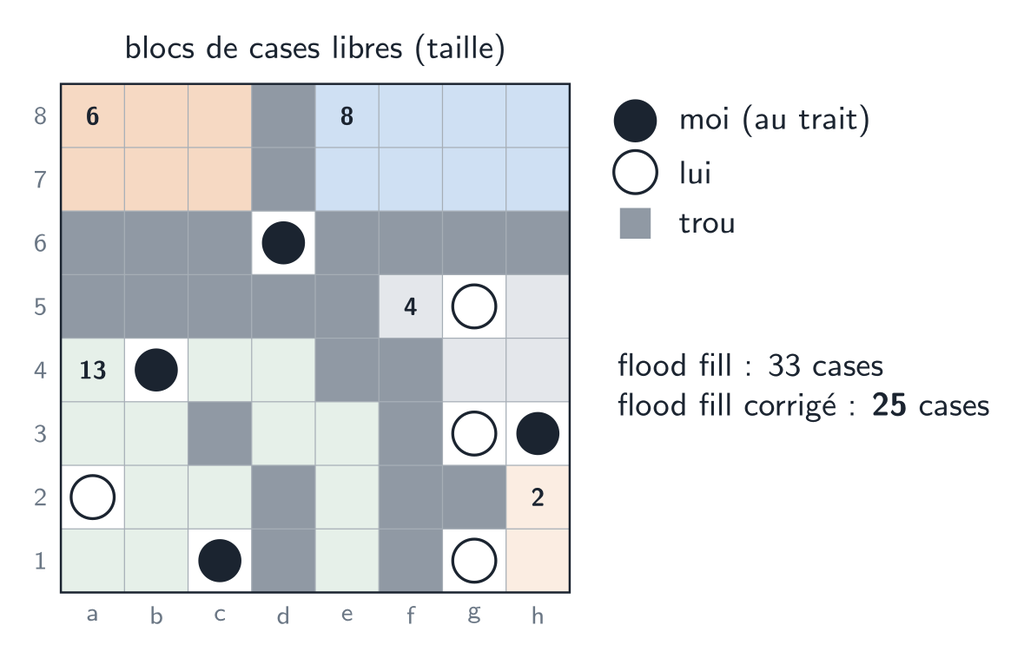

Figure 10: Le flood fill corrigé en finale. La pièce en d6 touche le bloc de 6 et celui de 8 : elle ne peut en garder qu’un. Celle en h3 touche le bloc de 4 et celui de 2. Les pièces b4 et c1 se partagent le bloc de 13. Flood fill : 13 + 4 + 2 + 8 + 6 = 33 cases ; corrigé : 13 + 4 + 8 = 25.

**Le code.** D’abord les blocs, une seule fois pour les deux camps : c’est le code de la section sur les blocs, extrait du début de `compute`. Ensuite CORR, pour chaque camp :

```cpp
// nnue/space_features.h, début de compute (simplifié : us, them, free sont ses paramètres)
//   us, them : les pièces du joueur au trait et de l'autre (bitboards)    free : les cases libres
//   out[0]   : CORR pour moi ;  out[8] : CORR pour lui (entier de 0 à 64)
void compute_corr(uint64_t us, uint64_t them, uint64_t free, uint8_t out[16]) {
    uint64_t comps[64];        // les blocs trouvés (un bitboard chacun) ; au plus 64
    int size[64], nc = 0;      // leur taille, leur nombre
    for (uint64_t rest = free; rest;) {                 // rest : les cases libres pas encore rangées
        uint64_t c = rest & -rest, prev = 0;            // c part de la première de ces cases
        // c grandit d'un pas de roi à la fois, dans les cases libres, jusqu'à ne plus changer :
        // c est alors tout le bloc de cette case
        while (c != prev) { prev = c; c |= shift_all_directions(c) & free; }
        comps[nc] = c;                                  // le bloc
        size[nc++] = std::popcount(c);                  // son nombre de cases
        rest &= ~c;                                     // ses cases sont rangées
    }
    const uint64_t pcs[2] = { us, them };
    for (int sd = 0; sd < 2; sd++)                      // sd = 0 : moi ; sd = 1 : lui
        out[sd * 8] = uint8_t(std::min(64, corrected_flood_fill(pcs[sd], free, comps, size, nc)));
}
```

Les deux camps partagent les blocs : ils ne dépendent que des cases libres, pas des pièces. Seules les options de chaque pièce (les blocs qu’elle touche) diffèrent. Dans le vrai code, `put` borne la valeur entre 0 et 64, comme ici `std::min`.

```cpp
// nnue/space_features.h
//   pieces : mes pièces (bitboard)          comps[i] : le bloc i (bitboard), calculé ci-dessus
//   free   : les cases libres (inutilisé    size[i]  : son nombre de cases
//            ici : les blocs suffisent)
//                                           nc       : le nombre de blocs
int corrected_flood_fill(uint64_t pieces, uint64_t free, const uint64_t* comps, const int* size, int nc) {
    uint64_t options[8];      // pour chaque pièce : les blocs qu'elle touche (bit i = bloc i)
    int np = 0, best = 0;     // le nombre de pièces, le meilleur total trouvé
    for (uint64_t b = pieces; b; b &= b - 1) {          // b & -b : une pièce ; b &= b - 1 : la suivante
        const uint64_t around = shift_all_directions(b & -b);   // ses 8 voisines
        uint64_t o = 0;
        for (int i = 0; i < nc; i++) if (comps[i] & around) o |= uint64_t(1) << i;
        options[np++] = o;
    }
    // rec(self, k, covered) : choisit le bloc de la pièce k, les pièces 0 à k − 1 ayant déjà pris les
    // blocs de covered (bit i = bloc i pris) ; self = rec elle-même (une lambda ne peut pas s'appeler
    // par son nom)
    auto rec = [&](auto&& self, int k, uint64_t covered) -> void {
        if (k == np) {                                  // tous les choix faits : taille des blocs pris
            int total = 0;
            for (uint64_t c = covered; c; c &= c - 1) total += size[std::countr_zero(c)];
            best = std::max(best, total);
            return;
        }
        const uint64_t avail = options[k] & ~covered;   // les blocs qu'elle touche et encore libres
        if (!avail) self(self, k + 1, covered);         // aucun : la pièce k ne prend rien
        for (uint64_t o = avail; o; o &= o - 1)         // sinon elle en prend un, chacun à son tour
            self(self, k + 1, covered | (o & -o));
    };
    rec(rec, 0, 0);                                     // de la pièce 0, aucun bloc pris
    return best;                                        // CORR
}
```

**Ce que les mesures ont dit.** Inutile en ouverture (le plateau est d’un seul bloc). En finale 10–19, c’est la meilleure mesure isolée du territoire : R² des points 70 % contre 47 % pour le flood fill classique ; la correction change le compte dans 53 % des positions. Ajouté au réseau : +18,6 points de R² (points) et +1,9 (résultat) en finale 10–19, +0,9 / +0,2 en milieu de partie.

**Le coût.** C’est la plus chère des 16 premières colonnes : environ 185 ns pour les deux camps (les blocs, puis la recherche exhaustive), mesurés avant la règle « s’abstenir seulement sans choix », qui retire environ 30 ns.

## 5.4 La distance de dame (Q1, Q2, Q3 et QW, 8 colonnes)

**L’idée.** Venue du jeu : être capable de couvrir beaucoup de cases en peu de coups. Une pièce qui atteint 20 cases en un coup et 40 en deux contrôle plus d’espace qu’une pièce enfermée.

**La définition.** Avec les niveaux de `queen_levels` pour toutes mes pièces ensemble :

- **Q1, Q2, Q3** : le nombre de cases libres que j’atteins en au plus 1, 2 et 3 coups de dame ;
- **QW** : la couverture pondérée $\left\lfloor \sum_k n_k \, 2^{-(k-1)} \right\rfloor$, où $n_k$ est le nombre de cases atteintes en exactement $k$ coups (pour $k \le 6$). Une case à 1 coup vaut 1, à 2 coups ½, à 3 coups ¼ : QW résume toute la courbe en un nombre.

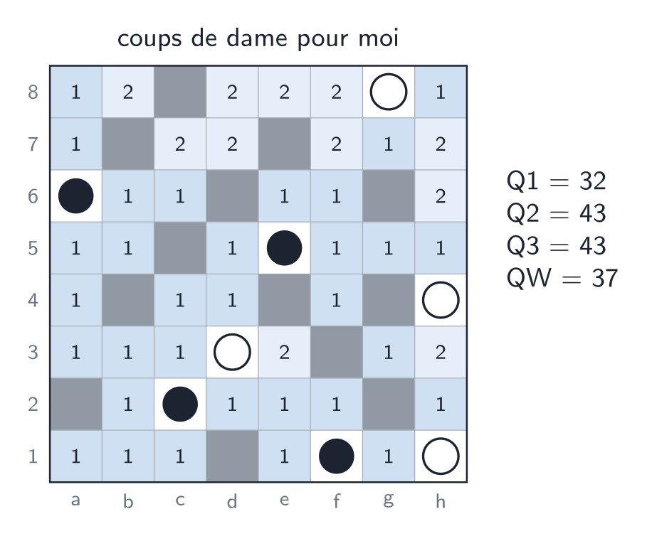

Figure 11: Le nombre de coups de dame qu’il me faut pour atteindre chaque case libre (toutes mes pièces ensemble). Q1 compte les cases marquées 1, Q2 celles marquées 1 ou 2, etc.

```cpp
// out : les 16 colonnes (out[0..7] pour moi, out[8..15] pour lui) ; une colonne = camp × 8 + numéro,
// le numéro venant de enum Id { CORR, Q1, Q2, Q3, QFIRST, QW, LATE9, MOB } (Q1 = 1, ..., MOB = 7)
uint8_t out[16];
// put(sd, id, v) : écrit v dans la colonne id du camp sd (0 = moi, 1 = lui), bornée à 0..64
auto put = [&](int sd, int id, int v) { out[sd * 8 + id] = uint8_t(std::clamp(v, 0, 64)); };
const uint64_t pcs[2] = { us, them };                   // les pièces de chaque camp
for (int sd = 0; sd < 2; sd++) {
    uint64_t lv[64];
    const int nl = queen_levels(pcs[sd], free, lv);     // lv[k] : les cases à k + 1 coups exactement
    uint64_t cover = 0;                                 // les cases atteintes jusqu'ici
    int w = 0, q[3] = {0, 0, 0};
    for (int k = 0; k < nl; k++) {
        cover |= lv[k];
        if (k < 3) q[k] = std::popcount(cover);         // Q1, Q2, Q3
        if (k < 6) w += std::popcount(lv[k]) << (5 - k);    // 32, 16, 8... = 2^-k en virgule fixe
    }
    for (int k = std::max(nl, 1); k < 3; k++) q[k] = q[k - 1];   // moins de 3 niveaux : Q2, Q3 = le dernier
    put(sd, Q1, q[0]); put(sd, Q2, q[1]); put(sd, Q3, q[2]); put(sd, QW, w >> 5);
}
```

`out` contient les 16 premières colonnes des deux camps : les 8 premières pour moi, les 8 suivantes pour lui, dans l’ordre de `enum Id`. Q2 de lui est donc la colonne 8 + 2 = 10. `put` évite d’écrire ce calcul d’indice à chaque fois, et ramène la valeur dans 0..64 : le réseau reçoit valeur / 64, et `out` est un tableau d’octets. Q1 à Q3 ne dépassent jamais 56 (les cases libres), mais MOB peut dépasser 64 en ouverture.

**Ce que les mesures ont dit.** Les cinq mesures de dame ensemble (avec QFIRST, ci-dessous) ajoutent au réseau +2,1 / +0,5 en milieu de partie. En finale 10–19, flood fill corrigé et distance de dame ensemble apportent +27,0 / +3,2 : plus que flood fill corrigé et influence (+22,3 / +2,0). Une fois la distance de dame présente, l’influence n’ajoute plus que +0,5.

## 5.5 Les cases atteintes en premier (QFIRST, 2 colonnes)

**L’idée.** Une case n’est vraiment à moi que si j’y arrive avant lui.

**La définition.** QFIRST compte les cases libres que j’atteins en **strictement moins** de coups de dame que lui (une case qu’il n’atteint jamais compte si je l’atteins). Les cases à égalité ne sont à personne.

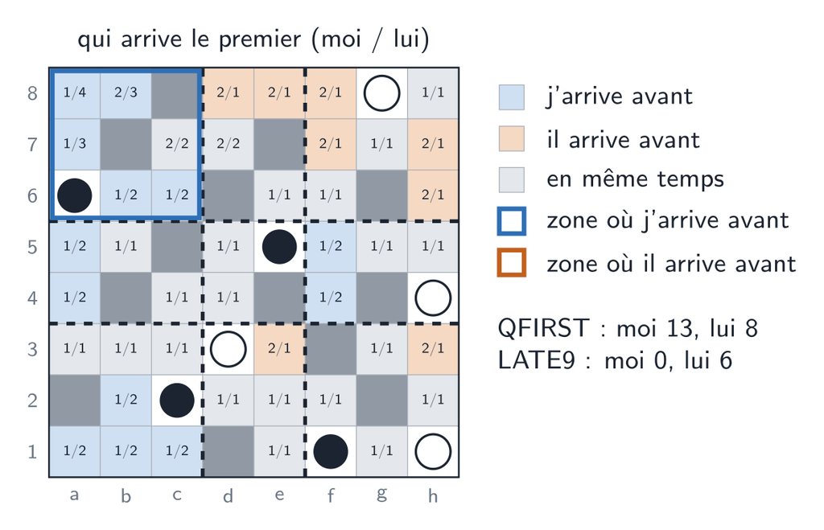

Figure 12: Pour chaque case libre : mes coups de dame / ses coups de dame. Bleu : j’arrive avant (QFIRST de moi) ; orange : il arrive avant (QFIRST de lui) ; gris : en même temps. Les traits pointillés découpent les 9 zones de LATE9 (section suivante).

```cpp
// lv[0], nl[0] : mes niveaux de dame ; lv[1], nl[1] : les siens
uint64_t seen0 = 0, seen1 = 0;                          // ce que chacun a atteint aux niveaux précédents
int first0 = 0, first1 = 0;                             // QFIRST de moi, de lui
for (int k = 0; k < std::max(nl[0], nl[1]); k++) {
    const uint64_t a = k < nl[0] ? lv[0][k] : 0, b = k < nl[1] ? lv[1][k] : 0;
    first0 += std::popcount(a & ~b & ~seen1);           // à moi au niveau k, ni à lui avant ni en même temps
    first1 += std::popcount(b & ~a & ~seen0);
    seen0 |= a; seen1 |= b;
}
```

**Ce que les mesures ont dit.** C’est la meilleure mesure isolée du milieu de partie : seule, elle explique 18,1 % des points restants (l’influence, 16,6 %).

## 5.6 Les zones où j’arrive en retard (LATE9, 2 colonnes)

**L’idée.** Remarque de jeu : être « en retard pour revenir dans une zone », avoir ses pièces trop concentrées quand l’adversaire est bien réparti.

**La définition.** Le plateau est découpé en 3 × 3 zones (colonnes a–c, d–e, f–h ; rangées 1–3, 4–5, 6–8). Pour chaque zone, on prend le nombre de coups de dame qu’il faut à chaque camp pour atteindre sa case libre la plus proche. LATE9 de moi = le nombre de cases libres des zones où **il** arrive strictement avant moi. Sur la figure précédente, la zone en haut à gauche (cadre bleu) est atteinte par moi en 1 coup, par lui en 2 : ses 6 cases libres comptent dans le LATE9 de lui. Aucune zone n’est en retard pour moi.

```cpp
// lv, nl comme ci-dessus ; zones9() : les 9 zones de la grille 3 × 3
auto first_level = [&](int side, uint64_t zone) {      // premier niveau du camp qui touche la zone
    for (int k = 0; k < nl[side]; k++) if (lv[side][k] & zone) return k;
    return 99;                                          // jamais
};
int late[2] = {0, 0};                                   // LATE9 de moi, de lui
for (int i = 0; i < 9; i++) {
    const uint64_t z = zones9()[i] & free;
    if (!z) continue;
    const int f0 = first_level(0, z), f1 = first_level(1, z);    // premier niveau qui touche la zone
    if (f1 < f0) late[0] += std::popcount(z);           // il y arrive avant moi
    if (f0 < f1) late[1] += std::popcount(z);
}
```

**Ce que les mesures ont dit.** Seule, elle explique 8,5 % des points en milieu de partie et 50,6 % en finale 10–19. Elle est en grande partie contenue dans les mesures de dame (les mesures de couverture, LATE9 en tête, n’ajoutent que +0,4 point à elles), mais presque gratuite une fois les niveaux de dame calculés. La simple dispersion géométrique des pièces (distance moyenne entre elles) ne prédit rien : ce qui compte, c’est le temps d’arrivée à travers les trous.

## 5.7 La mobilité (MOB, 2 colonnes)

**La définition.** Le nombre de coups légaux : pour chaque pièce, les cases libres qu’elle atteint en un coup de dame, comptées une fois **par pièce** (MOB ≥ Q1 : deux pièces qui visent la même case la comptent deux fois).

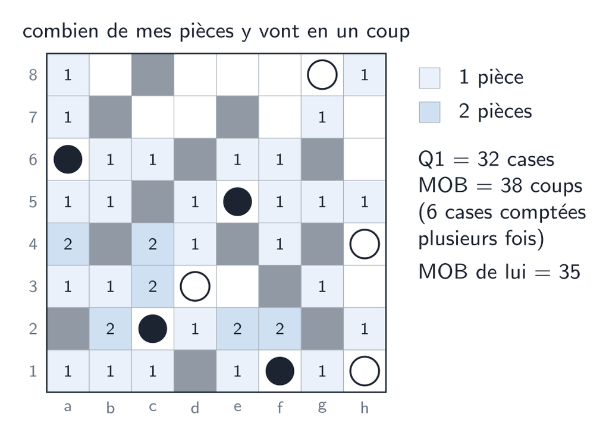

Figure 13: La mobilité, sur la position des coups de dame (Figure 11). Chaque case libre porte le nombre de mes pièces qui l’atteignent en un coup de dame. Q1 compte les cases numérotées (32) ; MOB additionne les nombres (38) : les 6 cases marquées 2 comptent deux fois, une fois pour chaque pièce qui peut y aller.

Sur la figure, a4 compte deux fois : la pièce en a6 y descend, celle en c2 y monte en diagonale. Q1 dit combien de cases je contrôle ; MOB dit combien de coups j’ai, donc combien de choix il me reste.

```cpp
int mob = 0;
for (uint64_t b = pieces; b; b &= b - 1)                // chaque pièce : ses coups de dame (tables magiques)
    mob += std::popcount(attacks_bb(Square(std::countr_zero(b)), ~free) & free);
```

**Ce que les mesures ont dit.** Seule, 8,7 % des points en milieu de partie. Asymétrie nette : la mobilité de l’adversaire pèse plus que la mienne (poids par écart-type, en plus du réseau : milieu +0,06 pour la mienne, −0,16 pour la sienne). C’est une raison de donner au réseau les deux valeurs séparément.

**Le coût des cinq dernières sections.** Q1–Q3, QW, QFIRST, LATE9 et MOB partagent les niveaux de dame : environ 160 ns ensemble pour les deux camps.

## 5.8 L’influence (INFL, 2 colonnes)

**L’idée.** La mesure de territoire de l’ordre des coups du joueur (`heuristic::influence`, +36 Elo dans l’étude J) : à qui revient chaque case si les deux camps s’étendent à la même vitesse.

**La définition.** Les deux camps s’étendent en même temps, d’un pas de roi à chaque tour, à travers les cases libres. Une case atteinte par les deux au même pas devient **neutre**, et la zone neutre s’étend elle aussi d’un pas à chaque tour, ce qui bloque les deux camps. INFL compte les cases libres que chaque camp possède à la fin.

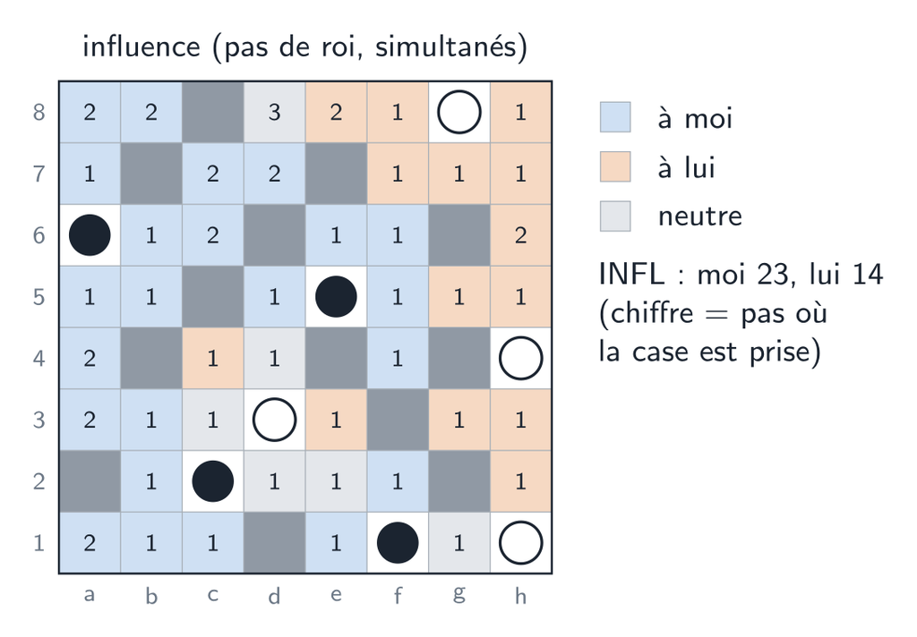

Figure 14: L’influence : à qui revient chaque case libre, et à quel pas elle est prise. La zone neutre (gris) s’étend aussi : c’est elle qui coupe l’avance des deux camps.

```cpp
auto step = [&](uint64_t b) { return shift_all_directions(b) & free; };
uint64_t own[2] = {us, them}, front[2] = {us, them}, neutral = 0, prev[2] = {0, 0};
while (prev[0] != own[0] || prev[1] != own[1]) {
    front[0] = step(front[0]) & ~own[1];
    front[1] = step(front[1]) & ~own[0];
    neutral |= step(neutral) | (front[0] & front[1]);   // atteintes ensemble, ou gagnées par le neutre
    front[0] &= ~neutral; front[1] &= ~neutral;
    prev[0] = own[0]; prev[1] = own[1];
    own[0] |= front[0]; own[1] |= front[1];
}
```

C’est exactement l’algorithme du joueur : sur 20 000 positions, la colonne est identique à `heuristic::influence`.

**Ce que les mesures ont dit.** Meilleure mesure isolée du milieu de partie avant QFIRST (16,6 % des points), mais en plus du réseau elle n’ajoute que +1,0 / +0,1, et presque rien une fois la distance de dame présente. Elle est candidate parce qu’elle ne coûte presque rien : 25 ns pour les deux camps.

## 5.9 La connectivité, pièce par pièce (CONNECT, 40 colonnes)

**L’idée.** Remarque de jeu : savoir si chacune de mes pièces est encore en contact avec les siennes, ou déjà séparée. La première version donnait 16 nombres, un par paire (ma pièce $i$, sa pièce $j$), avec les pièces numérotées par leur position sur le plateau. Mais le réseau ne sait pas laquelle de ses pièces est « la numéro 0 », et le numéro d’une pièce change dès qu’une autre passe devant elle : il ne peut qu’en faire une moyenne. D’où la question : comment identifier une pièce ?

**La réponse mesurée** (`nnue/piece_order_study.py`) : par son **rôle**, pas par sa position. On décrit chaque pièce par quelques nombres, puis on **trie** les pièces de chaque camp de la plus isolée à la moins isolée. Le premier emplacement est alors toujours « ma pièce la plus coupée », et son sens ne change pas d’une position à l’autre. Gain en plus du réseau et des 16 premières colonnes, milieu de partie (points | résultat) :

| Version | Colonnes | Milieu | Finale 10–19 |
| --- | --- | --- | --- |
| 16 paires, ordre du plateau | 64 | +0,23 \| +0,02 | +0,11 \| +0,04 |
| par pièce, ordre du plateau | 40 | +0,93 \| +0,08 | +0,33 \| +0,15 |
| **par pièce, la plus isolée d’abord** | 40 | **+1,42 \| +0,15** | +0,49 \| +0,20 |
| + la zone de la pièce (3 × 3) | 112 | +1,51 \| +0,20 | +0,51 \| +0,29 |

Le même contenu, mieux ordonné, gagne 50 % ; l’endroit où se trouve la pièce n’ajoute presque rien.

**La définition.** Pour chaque pièce, 5 nombres, face aux pièces de l’autre camp :

| Nombre | Définition | Codage |
| --- | --- | --- |
| block | les cases libres qu’elle atteint par pas de roi (ses blocs) | tel quel |
| contact | les pièces adverses qui touchent ces blocs | ×16 |
| king | les pas de roi pour arriver à côté de l’une d’elles | 64/d, 0 = jamais |
| go | les coups de dame pour arriver à côté de l’une d’elles | 64/d |
| come | les coups de dame pour que l’une d’elles arrive à côté d’elle | 64/d |

Les 4 pièces de chaque camp sont triées par (contact, block, king, go, come) croissants : la plus isolée d’abord.

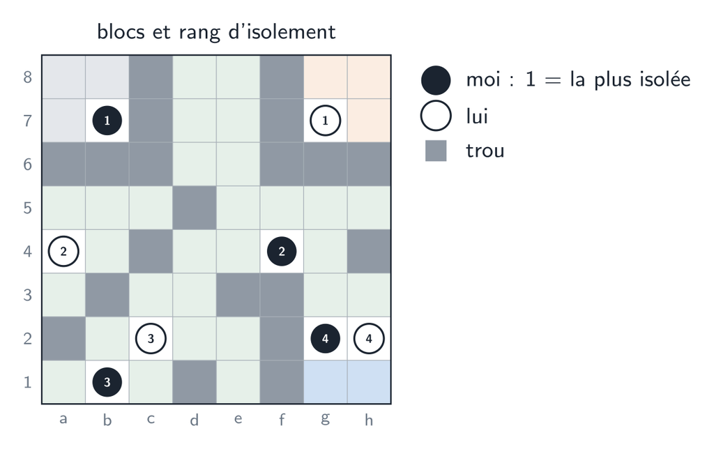

Figure 15: Les blocs (couleurs) et le rang d’isolement de chaque pièce. b7 et g7 sont seules dans leur petit bloc, sans contact : rang 1 de chaque camp.

Les 5 nombres de la figure, dans l’ordre où le réseau les reçoit :

| Pièce | block | contact | king | go | come |
| --- | --- | --- | --- | --- | --- |
| moi 1 : b7 | 3 | 0 | 0 | 0 | 0 |
| moi 2 : f4 | 28 | 48 (3 pièces) | 64 (1 pas) | 64 | 64 |
| moi 3 : b1 | 28 | 48 | 64 | 64 | 64 |
| moi 4 : g2 | 30 (deux blocs : 28 + 2) | 48 | 64 | 64 | 64 |
| lui 1 : g7 | 3 | 0 | 0 | 0 | 0 |
| lui 2 : a4 | 28 | 48 | 32 (2 pas) | 32 (2 coups) | 32 |
| lui 3 : c2 | 28 | 48 | 64 | 64 | 64 |
| lui 4 : h2 | 30 | 48 | 64 | 64 | 64 |

```cpp
// nnue/space_features.h — une pièce face aux pièces adverses (opp) ; opp_lv, opp_nl : les niveaux
// de dame des pièces adverses, calculés une fois pour les 4 pièces
std::array<int, 5> connect_piece(uint64_t piece, uint64_t opp, uint64_t free,
                                 const uint64_t opp_lv[], int opp_nl) {
    const uint64_t near_opp = shift_all_directions(opp);   // les cases à côté d'elles
    uint64_t seen = 0, front = piece;
    int king = 0;
    for (int d = 1; (front = shift_all_directions(front) & free & ~seen); d++) {
        if (!king && (front & near_opp)) king = d;          // premier pas qui arrive à côté de l'une
        seen |= front;
    }
    int contact = 0;
    for (uint64_t b = opp; b; b &= b - 1) contact += (shift_all_directions(b & -b) & seen) != 0;
    uint64_t lv[64];
    const int nl = queen_levels(piece, free, lv);          // les niveaux de dame de la pièce
    int go = 0, come = 0;
    for (int k = 0; k < nl && !go; k++) if (lv[k] & near_opp) go = k + 1;
    for (int k = 0; k < opp_nl && !come; k++) if (opp_lv[k] & shift_all_directions(piece)) come = k + 1;
    return {std::popcount(seen), 16 * contact, inverse64(king), inverse64(go), inverse64(come)};
}
```

**Le coût.** Un parcours par pas de roi et un par coups de dame pour chacune des 8 pièces : environ 650 ns pour les deux camps. C’est le groupe le plus cher, ce qui compte dans le choix.

## 5.10 L’encerclement (ENCIRCLE, 34 colonnes)

**L’idée.** Remarque de jeu : l’encerclement, ou le presque-encerclement, quand plusieurs de mes pièces gênent les mouvements d’une de ses pièces. C’est l’analogue des libertés au go.

**La définition, pour une pièce P** (face aux pièces de l’autre camp) :

| Nombre | Définition |
| --- | --- |
| lib | ses libertés : les voisines libres |
| opp | les voisines occupées par des pièces adverses |
| wall | les voisines qui sont des trous ou hors du plateau |
| own | les voisines occupées par ses propres pièces (lib + opp + wall + own = 8) |
| short | ses lignes qui n’ont que 1 ou 2 cases libres |
| gene | la **gêne** : les cases que les pièces adverses lui retirent = sa mobilité si elles étaient des cases libres, moins sa mobilité réelle (leurs cases comptent) |
| contrib | les pièces adverses qui arrêtent une de ses lignes en premier |
| att | ses libertés qu’une pièce adverse atteint en un coup de dame |
| fermable | lib = 1 et att ≥ 1 : on peut l’enfermer au coup suivant |

La menace (att, fermable) repose sur une règle propre à Yolah : la case qu’une pièce quitte devient un trou. Une pièce qui vient boucher la dernière liberté ne rouvre donc rien derrière elle : le bouchage tient toujours.

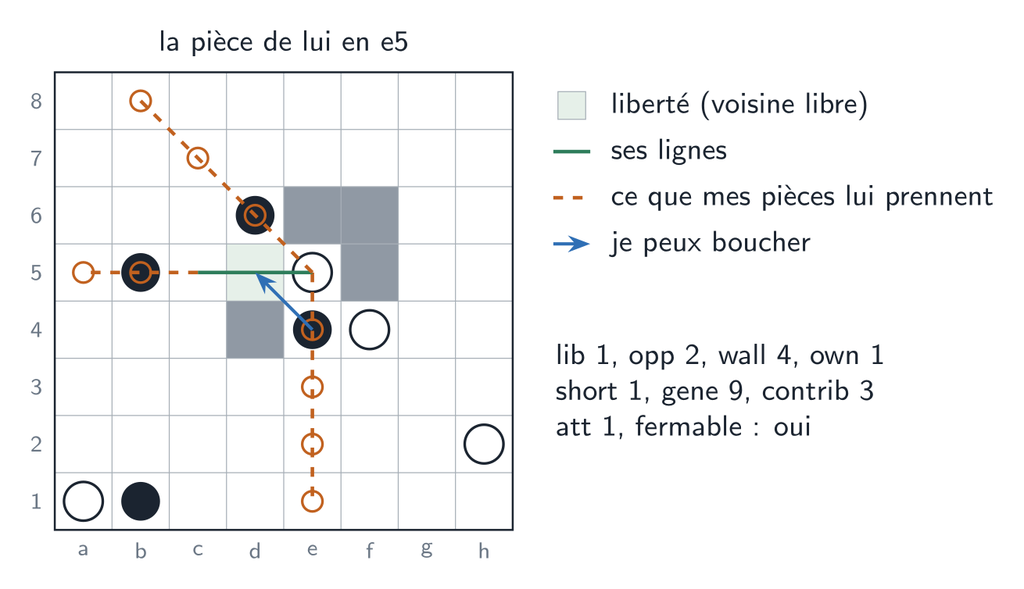

Figure 16: L’encerclement de la pièce de lui en e5. Ses lignes réelles (vert) ; en pointillé orange, ce que mes pièces lui retirent : en ôtant d6, b5 et e4, ses lignes continueraient (9 cases, celles de mes pièces comprises : gene = 9, par 3 pièces : contrib = 3). Sa seule liberté est d5, que ma pièce e4 peut occuper en un coup : elle est fermable.

```cpp
// nnue/space_features.h — une pièce face aux pièces adverses (opp) ; opp_reach1 : les cases libres
// qu'elles atteignent en un coup de dame
struct Encircle { int lib, opp, shrt, gene, contrib, att; };
Encircle encircle_piece(uint64_t piece, uint64_t opp, uint64_t free, uint64_t opp_reach1) {
    const uint64_t around = shift_all_directions(piece);
    Encircle e{std::popcount(around & free),                 // lib
               std::popcount(around & opp), 0, 0, 0,          // opp
               std::popcount(around & free & opp_reach1)};    // att : ses libertés qu'ils atteignent en 1 coup
    // ses coups de dame, puis les mêmes en comptant leurs pièces comme des cases libres
    // (queen_moves : tables magiques) ; rays()[case] : les 8 lignes d'une case sur un plateau vide
    const uint64_t all_real = queen_moves(piece, free), all_freed = queen_moves(piece, free | opp);
    for (const uint64_t ray : rays()[std::countr_zero(piece)]) {   // ses 8 lignes, une à une
        const uint64_t real = all_real & ray, freed = all_freed & ray;
        const int len = std::popcount(real);
        e.shrt += len == 1 || len == 2;
        e.gene += std::popcount(freed) - len;                // ce qu'ils lui prennent, leurs cases comprises
        e.contrib += (freed & opp) != 0;                     // la ligne s'arrête d'abord sur l'un d'eux
    }
    return e;
}
```

**Ce que le réseau reçoit** (`nnue/encircle_study.py`, version « compacte »). Pour chaque camp, l’encerclement de **ses** pièces par l’autre camp en 17 colonnes :

- 9 sommes sur ses 4 pièces : gene, 4 × contrib, 4 × opp, 2 × att, 2 × lib, 2 × short, et 16 × le nombre de pièces à au plus une liberté, sans liberté, fermables ;
- puis, ses pièces triées de la plus encerclée à la moins encerclée (le moins de libertés, puis la plus grande gêne, puis la plus attaquée), la menace de chacune : 8 × att et 64 × fermable.

**Ce que les mesures ont dit**, en plus du réseau et des 16 premières colonnes (points | résultat) :

| Version | Colonnes | Milieu | Finale 10–19 |
| --- | --- | --- | --- |
| par pièce, la plus encerclée d’abord (9 nombres) | 72 | +0,99 \| **+0,28** | +0,51 \| **+0,31** |
| sommes seulement | 18 | +1,41 \| +0,18 | +0,54 \| +0,26 |
| par pièce, sans la menace (att, fermable) | 56 | +0,73 \| +0,15 | +0,10 \| +0,04 |
| voisines seulement (lib, opp, wall, own) | 32 | +0,65 \| +0,12 | +0,08 \| +0,03 |
| **compacte : sommes + menace par pièce** | 34 | **+1,54 \| +0,23** | **+0,57 \| +0,29** |

C’est la **menace** qui apporte l’information nouvelle : sans elle, en finale, l’encerclement est déjà vu par le flood fill corrigé (+0,04 sur le résultat) ; avec elle, +0,31. C’est le meilleur gain sur le résultat parmi les candidats en plus des 16 premières colonnes. Une pièce fermable en un coup est rare (2,9 % des pièces en milieu de partie, 4,0 % en finale 10–19), mais décisive.

**Le coût.** Environ 200 ns pour les deux camps.

## 5.11 Récapitulatif

| Groupe | Colonnes | Pour | Coût (ns, deux camps) |
| --- | --- | --- | --- |
| CORR | 0, 8 | territoire réel en finale | 185 |
| QDIST (Q1, Q2, Q3) | 1–3, 9–11 | couverture en coups de dame | 160 avec les 4 suivants |
| QFIRST | 4, 12 | cases où j’arrive avant | (partagé) |
| QW | 5, 13 | couverture pondérée | (partagé) |
| LATE9 | 6, 14 | zones où j’arrive en retard | (partagé) |
| MOB | 7, 15 | coups légaux | (partagé) |
| INFL | 16, 17 | territoire par l’expansion simultanée | 25 |
| CONNECT | 18–57 | chaque pièce : isolée ou en contact | 650 |
| ENCIRCLE | 58–91 | pièces encerclées et menace de les enfermer | 200 |

En tout 92 colonnes, environ 1,5 µs par position si tout est gardé (mesuré par `space_features bench`), à comparer aux environ 1,1 µs de `value()` aujourd’hui. Le réseau entier n’a besoin que des groupes gardés : c’est l’objet de l’ablation.

# 6 L’ablation des caractéristiques

**La question.** Les mesures du chapitre précédent ajoutent chaque groupe à un modèle linéaire en plus du réseau. Le vrai juge est le réseau entier, entraîné avec les caractéristiques : un groupe que le réseau sait déjà recalculer, ou qu’un autre groupe contient, ne sert à rien et coûte du temps à chaque évaluation.

**Le protocole** (élimination descendante) :

1. **Référence.** Le réseau k8_them (étape 1) relit, en plus de ses deux accumulateurs, tous les groupes gardés, et il est réentraîné 5 époques (distillation, lr 1e-4) à partir de ses poids. Les colonnes nouvelles partent de 0 : au départ, le réseau donne exactement les valeurs de k8_them (vérifié).
2. **Une course par groupe.** La même chose sans ce groupe.
3. **Le coût de retirer un groupe** $g$, sur l’erreur de validation contre le maître après 5 époques :
   $$\text{coût}(g) = \frac{\text{mse}(\text{gardés} - g) - \text{mse}(\text{gardés})}{\text{mse}(\text{aucun}) - \text{mse}(\text{tous})}$$
   c’est-à-dire la part de ce qu’apportent toutes les caractéristiques qui est perdue sans $g$. Le même calcul est fait par phase de jeu (un groupe peut ne servir qu’en finale).
4. **On retire le groupe le moins coûteux** si son coût est faible (par défaut ≤ 5 % au total et ≤ 10 % dans chaque phase), et on recommence avec les groupes restants. On s’arrête quand chaque groupe restant coûte plus que ce seuil. À coût égal, on préfère retirer le groupe le plus cher à calculer.

**Le bruit.** Au premier tour, la référence est entraînée une seconde fois avec un autre ordre des données (`YOLAH_SEED=1`) : l’écart entre les deux dit à partir de quel coût une différence est réelle. Une course sans aucune caractéristique, entraînée de la même façon, donne l’échelle (le dénominateur du coût).

**En pratique** (`nnue/ablation.py`) :

```bash
# une fois, sur un nœud CPU : les 92 colonnes de chaque position du cache (≈ 1,5 µs par position)
sbatch -p insa-cpu --exclude=crn07,crn14,crn15 --export=ALL,COMMAND=compute-all nnue/space_features.sh

# un tour : le script écrit les sbatch (5 époques chacune, ~12 h sur un GPU)
python3 ablation.py plan --kept 0x1ff --round 1      # → ablation_r1.sh : 12 courses
bash ablation_r1.sh

# quand tout est fini : le tableau des coûts et la proposition pour le tour suivant
python3 ablation.py report /home/pgarcia/NNUE/DistillationNNUE/models_ablation --kept 0x1ff
```

Le premier tour compte 12 courses (référence, bruit, aucune caractéristique, et une par groupe) ; les suivants, une de moins à chaque groupe retiré (la référence d’un tour est une course du tour précédent). Chaque course écrit son erreur de validation, globale et par phase, dans `<modèle>.val.jsonl`, que `report` relit.

**Ce qui vient ensuite.** Le jeu de groupes retenu sera entraîné complètement, puis mesuré en match (joueur dev + nouveau réseau contre joueur dev + k8_them), car seule une partie dit si le gain de précision paie le temps de calcul. Le C++ de `NNUE_Persp` lit déjà n’importe quelles colonnes parmi les 92 (fichier de poids `PERSPC` : le nombre de colonnes puis les colonnes) et ne calcule que les groupes dont le réseau a besoin (`space::compute_groups`, identique à `compute_all` sur ces colonnes pour les 511 ensembles de groupes). Coût mesuré du calcul pour les deux camps : corr 150 ns, niveaux de dame (qdist, qfirst, qw, late9, mob) 125 ns, infl 22 ns, connect 640 ns, encircle 200 ns ; corr + encircle + infl : 380 ns.

# 7 Chercher les caractéristiques automatiquement : la recherche de programmes

## 7.1 L’idée

L’influence a été trouvée **à la main** : en jouant, on remarque que « à qui revient une case si les deux camps avancent à la même vitesse » prédit bien la suite, puis on l’écrit en quelques lignes de bitboards, et la mesure confirme qu’elle coûte 25 ns et apporte quelque chose. Peut-on faire faire ce travail à la machine ?

Une caractéristique comme l’influence est un **petit programme** : quelques opérations sur des bitboards, parfois une boucle, puis un `popcount`. On peut donc :

1. définir un **langage restreint** dont chaque programme calcule une caractéristique bon marché ;
2. donner à chaque programme une **note** : ce qu’il ajoute à la prédiction du réseau actuel, mesuré comme au chapitre précédent (Section 5.1.5) ;
3. lui donner un **prix** en nanosecondes, prédit puis vérifié en C++ ;
4. **chercher** dans ce langage les programmes qui apportent le plus pour le moins de temps, en partant des plus petits ;
5. **réutiliser** ce qui a été trouvé : une bonne caractéristique, une fois gardée, devient une brique du langage, et la recherche se met à chercher ce qu’elle n’apporte pas.

Ces cinq points reprennent, en version pratique, deux idées de Jürgen Schmidhuber. Le **Speed Prior** (2002) préfère, à qualité égale, les programmes courts *et* rapides. L’**OOPS** (*Optimal Ordered Problem Solver*, 2004) résout une suite de problèmes en réutilisant les solutions des précédents. Le tout tient dans `nnue/program_search.py` (1 300 lignes de Python et numpy), `test/program_search_dump_main.cpp` (les données) et `nnue/program_search.sh` (le lancement sur le cluster).

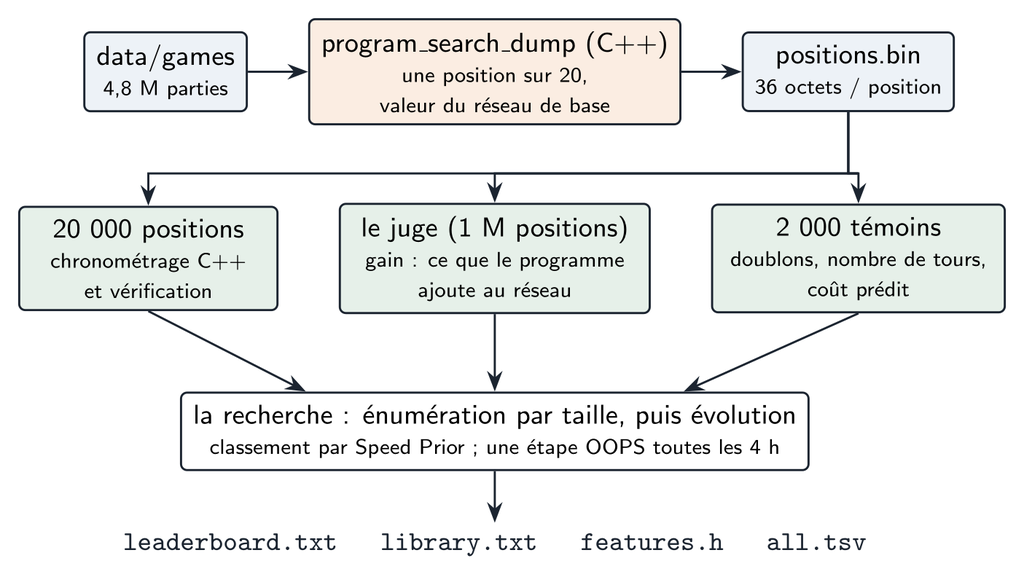

Figure 17: Le circuit de la recherche. Les positions sont extraites une fois par le C++. Trois échantillons servent ensuite à trois choses : noter (1 million de positions), reconnaître les doublons et compter les tours de boucle (2 000 témoins), chronométrer en C++ (20 000).

## 7.2 Les données

`program_search_dump` rejoue les parties de `data/games` avec le réseau de base (k8_them, mis à jour coup par coup comme dans la recherche) et garde une position sur 20, vue du joueur au trait :

```cpp
struct __attribute__((packed)) Rec {
    uint64_t mine, his, holes;   // mes pièces, les siennes, les trous
    float value;                 // ce que dit le réseau de base, dans [-1, 1]
    int8_t future, result;       // points restants, résultat (+1 / 0 / -1)
    uint8_t free, colour;        // nombre de cases libres, couleur au trait
    uint32_t game;               // numéro de partie (moitié d'apprentissage / moitié de test)
};                               // 36 octets
```

Sur les 4,8 millions de parties, cela donne 6,6 millions de positions en 9 secondes. Python les lit d’un coup avec `np.fromfile` : chaque champ devient un tableau numpy, et un programme s’évalue sur toutes les positions à la fois.

## 7.3 Le langage

### 7.3.1 Les briques

Un programme calcule un **ensemble de cases**, c’est-à-dire un bitboard de 64 bits. Il part de quatre ensembles connus :

| Feuille | Ensemble |
| --- | --- |
| `M` | mes pièces (le joueur au trait) |
| `H` | ses pièces |
| `F` | les cases libres |
| `X` | les trous |

Il les combine avec sept opérations :

| Opération | Résultat | Coût mesuré |
| --- | --- | --- |
| `N(s)` | les 8 voisines des cases de `s` | 1,4 ns |
| `S(s)` | `N(s) & F` : un pas de roi vers une case libre | 1,9 ns |
| `Q(s)` | un coup de dame depuis `s` à travers les cases libres (le *Kogge-Stone* de Section 5.2) | 8,8 ns |
| `C(s)` | tout ce qu’un roi atteint depuis `s` par les cases libres (`S` répété jusqu’à ce que rien ne change) | 4,0 ns par tour |
| `a & b`, `a \| b`, `a - b` | intersection, union, différence (`a & ~b`) | ≈ 0 |

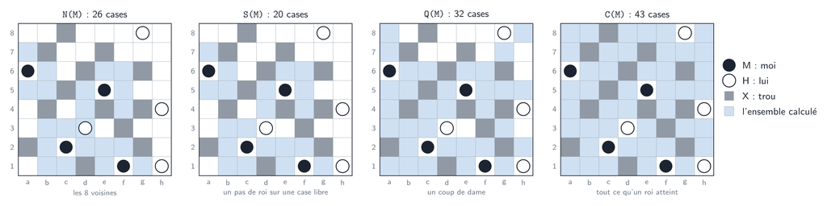

Figure 18: Les quatre opérations unaires appliquées à mes pièces, sur la position du milieu de partie déjà utilisée pour l’influence. `N` compte aussi les trous et les pièces voisines (en gris ou sous une pièce sur la figure) ; `S` ne garde que les cases libres.

La caractéristique est le **nombre de cases** de l’ensemble, qu’on écrit entre barres. Par exemple, sur la figure, `|S(M)|` = 20 et `|C(M)|` = 43. En Python, chaque opération est une fonction sur un tableau de bitboards (un par position) :

```python
def near(x):                       # N : les 8 décalages, avec les masques de bord
    out = np.zeros_like(x)
    for d, m in DIRS:              # (8, tout), (-8, tout), (1, pas la colonne a), …
        out |= sh(x, d, m)
    return out

def closure(x, free):              # C : S répété jusqu'au point fixe
    c = (x | near(x)) & free
    while True:
        n = c | (near(c) & free)
        if (n == c).all():
            return c
        c = n
```

Une expression est un arbre de tuples : `('S', ('Q', ('M',)))` s’écrit `S(Q(M))`. L’évaluation descend l’arbre et garde en cache les sous-expressions déjà calculées.

### 7.3.2 Les boucles : GROW et RACE

Sans boucle, le langage ne peut pas exprimer l’influence, qui fait avancer deux fronts tour après tour. Plutôt que d’ajouter des boucles quelconques, qui seraient difficiles à chercher et à chiffrer, le langage offre **deux modèles** de boucle. Chacun a un corps `g`, une expression qui peut lire un état :

- **`GROW[g]`** : un état `A`, qui part de mes pièces. À chaque tour, `A |= g(A)`, jusqu’à ce que rien ne change.
- **`RACE[g]`** : deux états, `A` qui part de mes pièces et `B` qui part des siennes. À chaque tour, chacun propose ses nouvelles cases : `g(A, B)` pour moi, et le même corps vu de l’autre côté, `g(B, A)`, pour lui. Une case proposée par les deux au même tour devient **neutre** pour toujours, et personne ne la prend.

Les deux boucles s’arrêtent quand rien ne change, ou au bout de 12 tours. Elles ont chacune deux sorties possibles : `#` compte les cases libres de `A`, et `w` les pondère par le tour où elles sont prises (32 au premier tour, 16 au deuxième…). Voici le cœur de `RACE` :

```python
A, B, neutral = M, H, 0
for k in range(MAX_ROUNDS):                       # 12
    a = g(A, B)        & ~A & ~neutral            # ce que je propose de nouveau
    b = swap(g)(A, B)  & ~B & ~neutral            # pareil pour lui : M↔H, A↔B
    both = a & b
    neutral |= both                               # proposées ensemble : neutres pour toujours
    a &= ~both; b &= ~both
    if not (a | b).any(): break
    A |= a; B |= b
me, him = popcount(A & F), popcount(B & F)        # sortie « # »
```

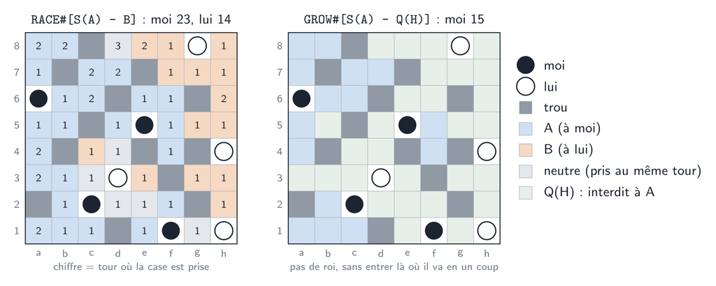

Figure 19: Les deux modèles de boucle. À gauche, `RACE#[S(A) - B]` : chaque camp avance d’un pas de roi sans entrer chez l’autre. Sur cette position, il donne exactement l’influence (23 et 14, comparer avec Figure 14). À droite, `GROW#[S(A) - Q(H)]` : j’avance d’un pas de roi sans jamais entrer sur une case qu’il atteint en un coup de dame (en vert).

**Le langage retrouve l’influence.** `RACE#[S(A) - B]` se lit « chacun avance d’un pas de roi, sans entrer chez l’autre ». C’est l’influence, à un détail près : dans l’influence, la zone neutre s’étend aussi d’un pas à chaque tour. Les deux sont égales sur 60 % des positions (corrélation 0,96), avec une note presque identique (0,512 contre 0,526). Le programme ne compte que 5 nœuds. Sans le `- B`, `RACE#[S(A)]` laisse chaque camp entrer chez l’autre et note moins bien (0,472). La différence entre les deux est exactement le genre de détail qu’une recherche essaie pour nous.

### 7.3.3 Pour moi et pour lui, et le miroir

Chaque programme donne **deux colonnes**, comme les caractéristiques du chapitre précédent : une pour moi, et le même programme vu de l’autre camp pour lui. Pour l’obtenir, `swap` échange `M` et `H` (et `A` et `B` dans une course) :

```python
def swap(e, ab=True):
    if len(e) == 1:
        return (swap_leaf(e[0], ab),)     # M↔H, A↔B, L1↔L1s (les briques, plus bas)
    return (e[0],) + tuple(swap(c, ab) for c in e[1:])
```

Toutes les opérations traitent les 8 directions de la même façon. Une position et son miroir donnent donc les mêmes valeurs, sans rien vérifier : la propriété exigée au chapitre précédent est acquise par construction.

## 7.4 La note : ce que le programme ajoute au réseau

La note est exactement la mesure de Section 5.1.5, appliquée aux deux colonnes du programme :

1. On ajuste d’abord la **base** : un polynôme de degré 3 de la valeur du réseau (plus les caractéristiques déjà gardées, plus bas), centré par groupe (cases libres, couleur), par phase, sur la moitié d’apprentissage des parties. On obtient ainsi le **résidu**, c’est-à-dire ce que le réseau se trompe.
2. Les deux colonnes du programme, centrées de même, prédisent ce résidu par une régression linéaire ajustée sur la même moitié.
3. Le **gain** est la part de la variance de la cible, sur l’autre moitié des parties, que cette prédiction retire, en points de R². On le calcule pour les deux cibles (points restants, résultat) et les quatre phases (40–56, 20–39, 10–19 et 0–9 cases libres), soit 8 gains.
4. La **note** est la moyenne de ces 8 gains, avec un poids 10 sur le résultat : pour la même information, un gain sur le résultat est environ dix fois plus petit.

```python
def gains(self, me, him):
    X = np.stack([self.center(me), self.center(him)], 1)
    for ph in range(4):
        tr, te = (self.phase == ph) & ~self.test, (self.phase == ph) & self.test
        for i, t in enumerate(["points", "result"]):
            coef = np.linalg.solve(X[tr].T @ X[tr] + 1e-6 * np.eye(2), X[tr].T @ self.resid[t][tr])
            r = self.resid[t][te]
            out[i, ph] = 100 * ((r ** 2).sum() - ((r - X[te] @ coef) ** 2).sum()) / self.sst[t][ph]
```

Une note se calcule en quelques dizaines de millisecondes sur un million de positions. Une recherche de 23 h sur 32 cœurs peut donc en noter des millions. Repères, sur la même échelle :

| Programme | Note | Coût mesuré (ns) |
| --- | --- | --- |
| `\|S(M)\|` | 0,197 | 3 |
| `\|S(S(S(M)))\|` | 0,382 | 9 |
| `\|C(M)\|` | 0,410 | 26 |
| `RACE#[S(A)]` | 0,472 | 32 |
| `RACE#[S(A) - B]` (≈ influence) | 0,512 | 20 |
| `GROW#[S(A) - Q(H)]` | 0,578 | 38 |
| influence (`heuristic::influence`) | 0,526 | 22 |
| QFIRST (chapitre précédent) | 0,573 | — |

## 7.5 Ne pas noter deux fois la même caractéristique

Beaucoup de programmes différents calculent la même chose pour le réseau. `|S(M) | X|` vaut `|S(M)| + (56 − free)` (les trous et les cases libres sont disjoints), soit `|S(M)|` plus une fonction du nombre de cases libres, que le centrage par groupe efface. `|F - S(M)|` vaut `free − |S(M)|`, la même information au signe près. Les noter tous remplirait le tableau de copies.

D’où l’**équivalence observationnelle** : on calcule les deux colonnes sur 2 000 positions **témoins**, puis on les normalise (centrées par nombre de cases libres, divisées par leur plus grande valeur, signe fixé par la première valeur non nulle) et on en tire une empreinte. Deux programmes de même empreinte sont la même caractéristique, et seul le **moins cher** est gardé.

```python
c = c - moyenne_par_nombre_de_cases_libres(c)        # pour chaque colonne
both = np.concatenate(cols) / np.abs(both).max()      # l'échelle
both = np.round(both * np.sign(first_nonzero), 6)     # le signe
key = blake2b(both.tobytes(), digest_size=12)
```

Sur les 620 expressions de taille 1 à 4, il ne reste que 179 caractéristiques distinctes. Les mêmes 2 000 témoins servent aussi à mesurer le nombre moyen de tours des boucles, dont le coût a besoin.

## 7.6 Le coût en nanosecondes

**1. Les prix des opérations.** Au démarrage, 160 programmes variés sont traduits en C++, compilés (`g++ -O3 -march=native`) et chronométrés sur 20 000 positions. Pour chacun, on compte combien de fois chaque opération s’exécute. Le prix de chaque opération est alors ajusté par **moindres carrés à coefficients positifs** : temps mesuré ≈ Σ nombre × prix. Cela prend 5 secondes, et l’ajustement colle aux mesures avec une corrélation de 0,995. Les prix obtenus sur le PC de test sont `N` 1,4 ns, `S` 1,9 ns, `Q` 8,8 ns, un tour de `C` 4,0 ns, un tour de boucle 1,4 ns ; les `&`, `|`, `-` et les `popcount` sont presque gratuits. Sur le cluster, la calibration est refaite sur le nœud : les prix sont ceux de son processeur.

**2. Les tours de boucle.** Le corps d’une boucle s’exécute (tours actifs + 1) fois, car le dernier tour calcule et ne trouve plus rien. On mesure cette moyenne par position sur les témoins : 3,6 tours pour `RACE#[S(A) - B]`, 3,2 tours de `C` par camp pour `C(M)`. Le premier prototype oubliait le « + 1 », et certaines boucles étaient alors sous-estimées jusqu’à 10 fois.

**3. Un graphe, pas un arbre.** Le C++ ne recalcule pas ce qu’il a déjà, donc le coût se compte sur le **graphe de calcul** :

- les deux camps sont fusionnés, et une sous-expression commune (`C(X)`, `N(F)`, ou `Q(Q(M))` qu’utilisent les deux corps d’une course) n’est payée qu’une fois ;
- une partie du corps de boucle qui ne lit pas l’état (`A`, `B`) est calculée une seule fois, avant la boucle ;
- ce que le moteur calcule déjà (les caractéristiques gardées, plus bas) est gratuit : le coût est **marginal**.

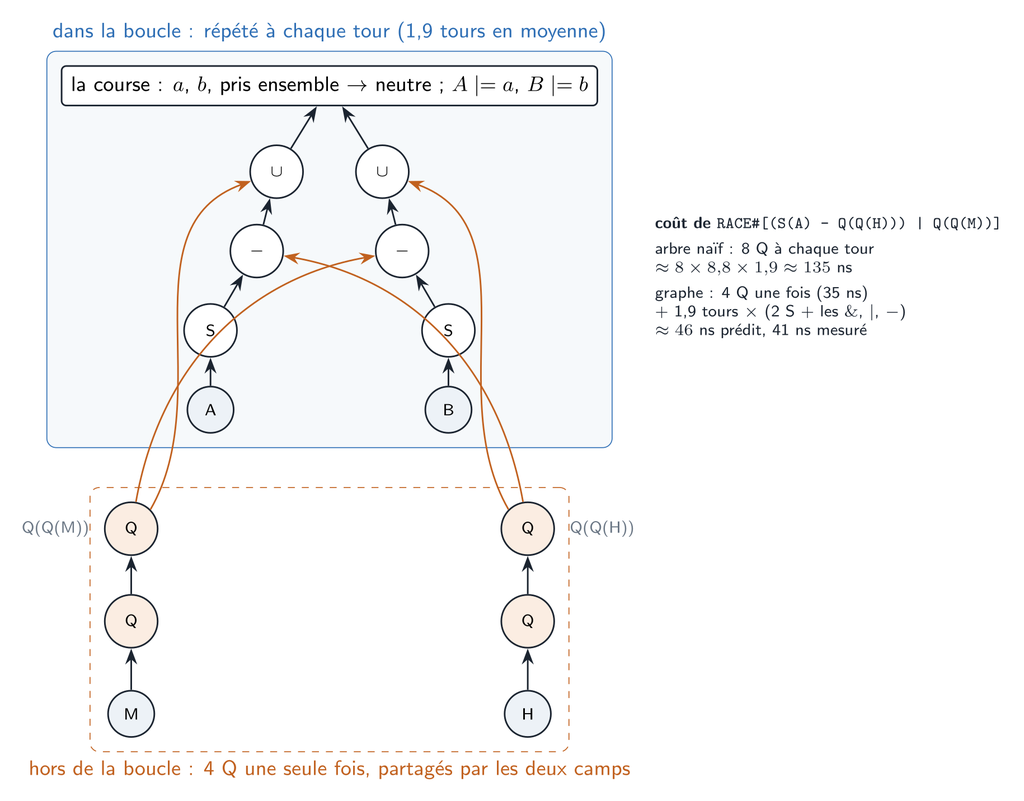

Figure 20: Arbre contre graphe, sur `RACE#[(S(A) - Q(Q(H))) | Q(Q(M))]`, la caractéristique gelée à la première étape d’un essai. Les quatre `Q` ne lisent pas l’état : ils sortent de la boucle et servent aux deux camps. Seuls les `S` et les opérations de bits se répètent à chaque tour.

```python
def walk(e, rounds):
    if len(e) == 1 or e in HAVE:                  # feuille, ou déjà calculé par le moteur : gratuit
        return
    m = rounds if uses_state(e) else 1.0          # hors de la boucle : une seule fois
    key = (e, m) if uses_state(e) else e
    if key in seen:                               # déjà compté (l'autre camp, ou ailleurs)
        return
    seen.add(key)
    counts[op_of(e)] += m
    for c in e[1:]:
        walk(c, rounds)

for e, rounds in [(g, r), (swap(g), r)]:          # les deux camps, un seul `seen`
    walk(e, rounds)
ns = sum(counts[k] * prices[k] for k in counts)
```

**4. La vérification en C++.** Toutes les 30 minutes, le front de Pareto et les 20 meilleurs programmes selon le Speed Prior sont traduits en C++, une ligne par nœud du graphe, puis compilés et chronométrés. Les sommes des colonnes sont comparées à celles de Python. Voici, par exemple, ce que le générateur écrit pour la caractéristique de la figure :

```cpp
const u64 v1 = qreach(M, F);           // hors de la boucle, partagés
const u64 v2 = qreach(H, F);
const u64 v3 = qreach(v2, F);          // Q(Q(H))
const u64 v4 = qreach(v1, F);          // Q(Q(M))
u64 A = M, B = H, neu = 0;
for (int k = 0; k < 12; k++) {
  const u64 v5 = near_(A) & F;         // S(A)
  const u64 v6 = v5 & ~v3;             // − Q(Q(H))
  const u64 v7 = v6 | v4;              // | Q(Q(M))
  const u64 v8 = near_(B) & F;         // et de son côté
  const u64 v9 = v8 & ~v4;
  const u64 v10 = v9 | v3;
  u64 a = v7 & ~A & ~neu, b = v10 & ~B & ~neu; const u64 both = a & b;
  neu |= both; a &= ~both; b &= ~both; if (!(a | b)) break;
  A |= a; B |= b; }
out[0] = pc(A & F); out[1] = pc(B & F);
```

Le chronomètre recalcule tout, y compris ce que les caractéristiques gardées fournissent déjà. Il est donc comparé au coût prédit **hors partage**. Sur l’essai local, le rapport prédit / mesuré est entre 0,98 et 1,06, la corrélation entre 0,98 et 1,00, et il n’y a **aucune différence de valeurs** entre C++ et Python. Le tableau affiche les deux : `ns`, le coût marginal prédit, qui sert au classement, et `mes.`, le temps mesuré seul.

## 7.7 Le Speed Prior : préférer le court et le rapide

Chaque programme a maintenant une note et un prix. Lequel est le meilleur ? Le meilleur score tout court favoriserait des programmes énormes et lents, qui gagnent 0,01 de plus pour trois fois le temps. Le **front de Pareto**, c’est-à-dire les programmes qu’aucun programme moins cher ne bat, montre tous les compromis, mais ne choisit pas.

Le *Speed Prior* de Schmidhuber donne à un programme une probabilité a priori proportionnelle à $2^{-\text{longueur}} / \text{temps}$. En prenant le logarithme, et en le mélangeant à la note :

$$\text{sp} = \text{note} - \lambda \log_2(\text{ns}) - \mu \cdot \text{nœuds}, \qquad \lambda = 0{,}03,\ \mu = 0{,}002$$

Ce qui se lit simplement :

- **doubler le temps** doit rapporter au moins 0,03 de note ;
- **un nœud de plus** doit rapporter au moins 0,002. Ce terme casse les égalités en faveur du programme le plus lisible, et freine l’enflure des programmes au fil de l’évolution.

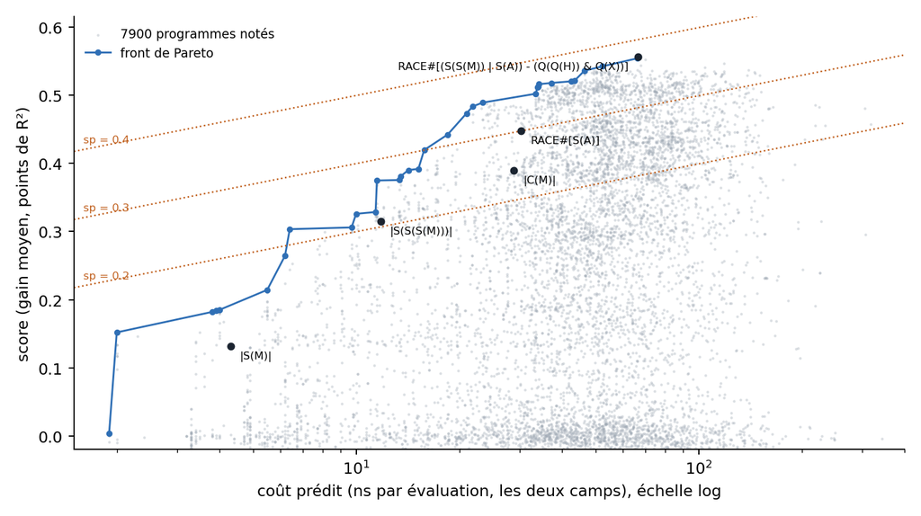

Figure 21: Les 7 900 programmes notés pendant les premières minutes d’un essai local (60 000 positions), selon leur coût prédit (échelle log) et leur note. En bleu, le front de Pareto. En pointillé, les droites de même Speed Prior : un programme est meilleur selon le Speed Prior s’il est au-dessus d’une droite plus haute.

## 7.8 La recherche : énumérer, puis faire évoluer

**1. L’énumération par taille.** Tous les ensembles jusqu’à 6 nœuds, puis toutes les boucles dont le corps a jusqu’à 5 nœuds, sont construits du plus petit au plus grand. Chacun passe par les témoins (doublons, coût), puis, s’il est nouveau, par la note. Quelques règles évitent les cas inutiles : `a & b` et `b & a` ne sont essayés qu’une fois, et pas de `S(C(…))`, car `C` est déjà fermé.

**2. L’évolution**, jusqu’à la fin du temps. Les parents sont les 50 meilleurs selon sp, les 20 mieux notés et le front de Pareto, tous limités à 15 nœuds. Chaque génération produit 256 enfants par mutation :

- remplacer un sous-arbre par un sous-arbre au hasard ;
- envelopper un nœud dans `N`, `S`, `Q`, `C`, ou dans un `&`, `|`, `-` avec un sous-arbre nouveau ;
- changer d’opérateur, remplacer un nœud par l’un de ses enfants ;
- croiser deux parents (`a | b` entre deux ensembles) ;
- passer d’un ensemble à une boucle, de `GROW` à `RACE`, de la sortie `#` à `w`.

Tout se calcule en parallèle sur les 32 cœurs du nœud. Chaque nouveau record s’affiche tout de suite :

```
[ 42.0 min] MEILLEUR SP  score 0.582 sp 0.393 ns 46.4 mes. 41.0 | points 0.13 1.40 9.25 11.02 | résultat 0.00 0.18 0.19 0.01 | RACE#[(S(A) - Q(Q(H))) | Q(Q(M))]
[ 43.1 min] front        score 0.512 sp 0.370 ns 20.8 mes.    - | points 0.07 0.74 8.97 10.98 | résultat 0.00 0.02 0.14 0.01 | RACE#[S(A) - B]
```

(Ces deux lignes illustrent le format ; les minutes sont fictives.) Le tableau complet (`leaderboard.txt`) est réécrit chaque minute : la bibliothèque, les 40 meilleurs selon sp, les 20 mieux notés et le front de Pareto. `all.tsv` garde tous les programmes notés.

## 7.9 Les étapes OOPS : réutiliser ce qui a été trouvé

Une fois une bonne caractéristique de territoire trouvée, la recherche risque de proposer cent variantes de la même idée. Ce qui compterait ensuite, c’est ce qu’**elle n’apporte pas**. Toutes les 4 heures, une **étape** gèle donc le meilleur programme selon sp, si sa note dépasse 0,05 :

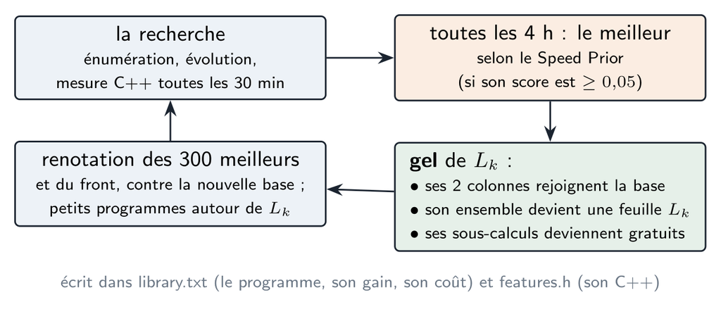

Figure 22: Une étape OOPS. Le programme gelé change trois choses : la base (on cherche désormais ce qu’il n’apporte pas), le langage (une nouvelle feuille) et les prix (ses sous-calculs deviennent gratuits).

```python
LIBRARY.append(e.p)                               # L{k} : feuille du langage (Lk pour moi, Lks pour lui)
for s in subexprs(e.p[1]) | subexprs(swap(e.p[1])):
    if not uses_state(s):
        HAVE.add(s)                               # le moteur les calcule déjà : gratuits
self.scorer.add_base(me, him)                     # ses 2 colonnes rejoignent la base → nouveaux résidus
# renoter les 300 meilleurs et le front contre la nouvelle base ; essayer |Lk|, |S(Lk)|, |Lk - M|, …
```

**La base grandit.** Les deux colonnes rejoignent le polynôme de la valeur. Les notes suivantes mesurent ce qu’un programme ajoute *au réseau et aux caractéristiques gelées*. Les 300 meilleurs programmes sont renotés, et une variante de `L1` tombe aussitôt près de 0.

**Le langage grandit.** L’ensemble final du programme gelé devient une feuille, `L1` pour moi et `L1s` pour lui. Un programme comme `|L1 - N(F)|` (« mes cases de `L1` qui touchent une case libre ») ne coûte que quelques opérations de bits. C’est le principe d’OOPS : une solution trouvée sert de sous-programme aux suivantes.

**Les prix baissent.** Le moteur calcule déjà `L1`, et aussi ses sous-expressions sans état (ici `Q(M)`, `Q(Q(M))`…). Elles deviennent gratuites, et un programme qui les réutilise ne paie que ce qu’il ajoute.

Chaque étape s’affiche `===== ÉTAPE k : Lk = … =====`. `library.txt` garde le programme, sa note et son coût, et `features.h` contient le C++ des caractéristiques gelées, prêt à copier dans le moteur :

```cpp
// L1 = the set of RACE#[(S(A) - Q(Q(H))) | Q(Q(M))]
static inline u64 lib1(u64 M, u64 H, u64 X, u64 F, const u64* Lm, const u64* Lh) {
    const u64 v1 = qreach(M, F);
    ...
    return A;
}
// la caractéristique : popcount(lib1(M, H, …) & F) pour moi, popcount(lib1(H, M, …) & F) pour lui
```

## 7.10 Ce qu’ont montré les essais locaux

Les essais locaux (60 000 à 100 000 positions, 7 à 20 minutes, une étape toutes les 3 minutes) ont servi à mettre l’outil au point. Ils disent déjà trois choses :

1. **Le langage retrouve les caractéristiques connues** : `RACE#[S(A) - B]` (≈ influence, 0,512), et des courses qui égalent QFIRST (0,573) pour 20 à 40 ns.
2. **La première étape gèle toujours une course de territoire**, de note 0,54 à 0,60 pour 32 à 47 ns mesurées. Par exemple `L1 = RACE#[(S(A) - Q(Q(H))) | Q(Q(M))]` : 0,536 (sur 60 000 positions), 46 ns prédites, 47 ns mesurées. Ses gains sont presque tous en finale, sur les points restants (+9,1 en 10–19, +10,4 en 0–9).
3. **Après elle, il reste peu** : les meilleures notes tombent vers 0,05–0,1, par exemple `L2 = |N(F) & ((Q(H) | L1) | Q(Q(H)))|`, note 0,097 pour 2 ns marginales. Une seule caractéristique de territoire capte donc l’essentiel de ce que la base linéaire voit manquer au réseau.

**Les limites.**

- Le juge est **linéaire** : une caractéristique utile seulement en combinaison avec les accumulateurs du réseau peut être sous-notée. Le vrai juge reste l’entraînement du réseau avec la colonne, comme dans l’ablation.
- La cible est la **partie jouée**, bruitée sur le résultat : le poids 10 l’amplifie, mais les gains sur le résultat restent proches du bruit.
- Le langage ne voit que des ensembles et des comptes. Il ne peut pas exprimer « par pièce » (comme CONNECT) ni « la plus petite distance ». On pourrait l’étendre si la grosse recherche montre que le territoire est épuisé.

## 7.11 En pratique

```bash
cd ~/Yolah && git pull
sbatch -p insa-cpu --exclude=crn07,crn14,crn15 nnue/program_search.sh
tail -f yolah_progsearch_<job>.out                         # MEILLEUR, MEILLEUR SP, front, mesures C++, ÉTAPES
cat ~/SearchStudy/program_search/run_*/leaderboard.txt     # le tableau, réécrit chaque minute
cat ~/SearchStudy/program_search/run_*/library.txt         # les caractéristiques gelées
```

**Ce que fait le script :**

1. La première fois seulement, il extrait les positions (`positions_<base>_s20.bin`, une position sur 20).
2. Il lance la recherche pour 23 h sur 32 cœurs, sur 1 million de positions.

Les réglages se changent par variables d’environnement, avec `--export=ALL,…` :

| Variable | Défaut | Rôle |
| --- | --- | --- |
| `MINUTES` | 1380 | durée de la recherche |
| `N` | 1 000 000 | positions notées |
| `LAM`, `MU` | 0,03, 0,002 | Speed Prior : prix d’un doublement du temps, d’un nœud |
| `STAGE_MINUTES`, `MIN_GAIN` | 240, 0,05 | étapes OOPS : fréquence, note minimale gelée |
| `MEASURE_MINUTES` | 30 | chronométrage C++ du front |
| `BASE_FEATURES` | aucune | caractéristiques connues ajoutées à la base (`infl,qfirst,mob`), pour chercher ce qu’elles n’apportent pas |
| `HAVE` | aucune | expressions que le moteur calcule déjà (gratuites), séparées par `;` |
| `WEIGHTS` | `1,10` | poids des gains sur les points et sur le résultat |
| `MAX_SIZE`, `BODY_SIZE`, `MAX_NODES` | 6, 5, 15 | tailles de l’énumération et de l’évolution |

Une caractéristique trouvée ne sert qu’une fois validée comme les autres : on l’ajoute aux colonnes du réseau, on réentraîne, puis on la mesure en match.

# 8 Améliorer le réseau lui-même : le chemin direct et l’entraînement conscient de la quantification

## 8.1 Pourquoi changer de cap

Les campagnes P3, P4 et P5 ont cherché le gain dans de **nouvelles entrées** : spacelite (14 space features) bat le réseau sans features de 18 Elo, et c’est le meilleur résultat obtenu. Toutes les tentatives suivantes ont été neutres ou négatives :

| campagne | réseau, contre spacelite | 1 s | 0,2 s | pourquoi |
| --- | --- | --- | --- | --- |
| P3 | space (+ CORR) | −60 | −64 | CORR coûte 150 ns par évaluation |
| P4 | g147, g146, g141 (encerclement, connectivité) | −21 à −71 | −20 à −62 | +18 à 24 % de temps par évaluation |
| P5 | g040 (influence seule) | −4 | 0 | aussi bon, pas meilleur |
| P5 | g07e (spacelite + influence) | −10 | −9 | l’influence n’ajoute rien à spacelite |
| P5 | g046 (qdist + qfirst + influence) | −24 | −28 | qdist et qfirst coûtent plus qu’ils n’apportent |

La leçon est toujours la même : **une feature se paie en nanosecondes à chaque évaluation**, et l’erreur de validation qu’elle fait gagner ne suffit pas à payer ce coût. L’étape 3 fait donc l’inverse : ne rien ajouter aux entrées, et récupérer deux pertes que le réseau actuel subit **sans rien coûter de plus à l’exécution**.

1. **L’arrondi.** Le réseau est entraîné en nombres flottants, puis arrondi en entiers de 8 bits pour le C++. Cet arrondi déforme la valeur : 0,036 d’erreur moyenne sur spacelite, 0,92 au pire, et 9 positions sur 2000 dont la valeur change de signe. Le remède est l’**entraînement conscient de la quantification** (*quantization-aware training*, QAT).
2. **La saturation.** Les space features n’atteignent la valeur qu’à travers fc2, dont les poids sont bornés à $\pm 127/64 \approx \pm 2$ pour tenir en int8. Dans spacelite, pour la colonne QFIRST de l’adversaire, 51 des 512 lignes de fc2 sont collées à cette borne (de 3 à 21 pour les autres features), contre 0,3 % des poids pour les colonnes de l’accumulateur : le réseau voudrait donner plus de poids à ces features et ne le peut pas. Le remède est un **chemin direct**, sans borne, des features vers la valeur.

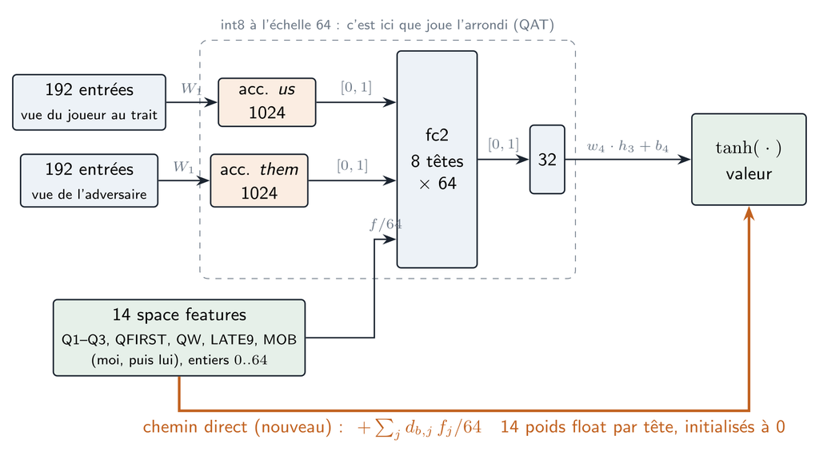

Figure 23: Le réseau spacelite et le chemin direct ajouté par l’étape 3. Tout ce qui est dans le cadre pointillé est en int8 et subit l’arrondi ; le chemin direct est en float.

## 8.2 Ce que fait vraiment le C++ : la quantification pas à pas

Pour comprendre le QAT, il faut d’abord voir précisément ce que calcule `NNUE_Persp::value()` (`nnue/nnue_persp.cpp`). Tout y est un **entier à l’échelle 64** : l’entier $k$ représente le nombre $k/64$.

**Les poids.** L’export (`export_value_nets.py`) multiplie chaque poids par 64 et l’arrondit à l’entier le plus proche, borné à $[-127, 127]$ :

$$w = 0{,}3 \;\longrightarrow\; 64 \times 0{,}3 = 19{,}2 \;\longrightarrow\; 19 \;\text{(int8)}, \qquad
\text{qui vaut } 19/64 = 0{,}296875 .$$

L’erreur sur ce poids est petite (0,003), mais fc2 additionne plus de 2000 produits, et chacun porte son erreur. Les biais sont arrondis de la même façon, à l’échelle 64 pour fc1 et $64 \times 64 = 4096$ pour fc2 et fc3 (ils s’ajoutent à des sommes de produits de deux nombres à l’échelle 64).

**L’accumulateur et $h_1$.** L’accumulateur est la somme des lignes int8 de $W_1$ des entrées actives, plus le biais : un entier, sans autre arrondi. $h_1$ est cet entier borné à $[0, 64]$, c’est-à-dire le nombre borné à $[0, 1]$. Rien de nouveau ici, à part l’arrondi des poids.

**fc2 et fc3 : le décalage `>> 6`.** Une sortie de fc2 est une somme d’entiers $\sum_i W_i h_i + B$, où $W_i$ et $h_i$ sont à l’échelle 64 : la somme est donc à l’échelle $64 \times 64$. Pour revenir à l’échelle 64, le C++ la **décale de 6 bits vers la droite**, ce qui revient à diviser par 64 en arrondissant **vers le bas** :

```cpp
outval = _mm256_srai_epi32(outval, SHIFT);                              // ÷ 64, vers le bas
outval = _mm256_min_epi32(_mm256_max_epi32(outval, zero), factor);     // borné à [0, 64]
```

Exemple : une somme qui vaut 0,4937 en flottant devient $\lfloor 0{,}4937 \times 64 \rfloor = \lfloor 31{,}6 \rfloor = 31$, soit 0,484 : l’activation a perdu 0,009. Ce n’est **pas un arrondi au plus proche** : chaque neurone de fc2 et de fc3 perd en moyenne une demi-graduation, $1/128$. C’est un **biais systématique** que le réseau flottant n’a jamais vu pendant son entraînement.

**La tête de valeur** est en float : $\tanh(w_4 \cdot h_3 + b_4)$, sans arrondi.

Au total, la valeur du C++ s’écarte de celle du réseau entraîné (Figure 24, à droite) : écart médian 0,012, moyen 0,036, plus de 0,1 sur 8,6 % des positions, jusqu’à 0,92 (une position que le réseau float juge gagnée à 0,79 vaut −0,13 en C++). Dans les unités de la recherche (×30 000), l’écart moyen fait environ 1 100 points, du même ordre que les marges des élagages (3 000 par ply pour le *reverse futility pruning*).

## 8.3 L’entraînement conscient de la quantification (QAT)

### 8.3.1 L’idée

Puisque le C++ calcule avec des poids arrondis et des activations tronquées, autant **entraîner le réseau qui calcule exactement cela**. Le passage avant de l’entraînement simule donc les arrondis du C++ :

- chaque poids est remplacé par $\mathrm{round}(64 w)/64$, borné à $\pm 127/64$ ;
- chaque biais par son arrondi à l’échelle 64 ou 4096 ;
- chaque sortie de fc2 et de fc3 par $\lfloor 64 x \rfloor / 64$ avant d’être bornée à $[0, 1]$.

La perte est alors calculée sur la valeur **que le C++ donnera**, et l’optimiseur cherche des poids dont la version **arrondie** est bonne, au lieu de chercher de bons poids et de les arrondir après coup. Il peut par exemple remonter un biais d’une demi-graduation pour compenser la troncature de la sortie, ou éviter de laisser un poids important pile entre deux entiers.

### 8.3.2 Le problème : l’arrondi n’a pas de dérivée

L’apprentissage avance en suivant le gradient. Or la fonction $\mathrm{round}$ est un escalier (Figure 24, à gauche) : sa dérivée est nulle partout, sauf aux marches où elle n’existe pas. Un gradient qui traverse un arrondi devient nul, et plus rien n’apprend.

La solution standard est l’**estimateur « straight-through »** (STE) : au passage avant on arrondit, au passage arrière on fait **comme si l’arrondi était l’identité**. En PyTorch, une ligne suffit :

```python
# nnue/nnue_persp.py
def ste(x, xq):
    """xq dans le passage avant, le gradient de x dans le passage arrière."""
    return x + (xq - x).detach()
```

`(xq - x).detach()` est une constante pour le gradient : le résultat vaut `xq` (la valeur arrondie), mais sa dérivée par rapport à `x` vaut 1. Les poids « maîtres » restent donc des flottants, que le gradient fait bouger par petits pas ; un poids change de valeur effective quand il franchit une marche. Ce sont ces poids maîtres que l’export arrondit, exactement comme le passage avant l’a fait.

```python
def q_weight(w):     # int8 à l'échelle 64, comme export_value_nets.py (arrondi au pair, comme round())
    return ste(w, torch.clamp(torch.round(w * 64), -127, 127) / 64)

def q_floor(x):      # le >> 6 des sommes int32
    return ste(x, torch.floor(x * 64) / 64)

# dans forward, si qat :
h2 = torch.clamp(q_floor(nn.functional.linear(h1, q_weight(fc2.weight), q_bias(fc2.bias, 4096))), 0, 1)
```

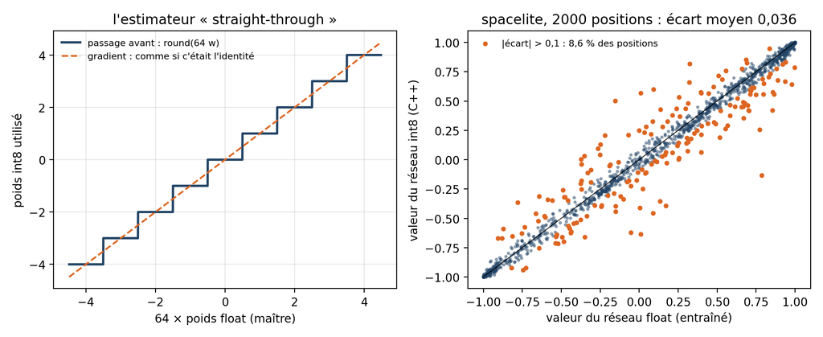

Figure 24: À gauche : un poids vu par le passage avant (l’escalier de l’arrondi) et par le gradient (l’identité). À droite : la valeur de spacelite sur 2000 positions, réseau float contre réseau int8 du C++ ; c’est cet écart que le QAT supprime.

### 8.3.3 Deux détails qui comptent

- **Le QAT s’entraîne en float32.** L’entraînement habituel utilise le bf16 (8 bits de mantisse) pour aller plus vite. Le bf16 ne sait pas représenter exactement la grille $1/64$ d’une somme de 2000 produits : l’arrondi simulé serait faux. En float32 (avec les entrées TF32, exactes pour des nombres $q/64$ avec $|q| \le 127$), la simulation est exacte. Et ce n’est pas plus lent : sur une RTX 3080, un pas de 1024 positions prend 5,3 ms en float32 contre 9,0 ms en bf16 (le réseau est trop petit pour que le bf16 rapporte quelque chose, et les conversions coûtent).
- **La simulation est vérifiée au bit près.** Un réseau QAT, passé à `check_persp_net.py` (la valeur PyTorch de 2000 positions) puis à `nets_check check_persp` (la valeur C++ des mêmes positions), donne un écart **maximal de 0,00000**. Le même test sur spacelite tel quel, en activant seulement la simulation, donne aussi 0 : ce que le QAT optimise est exactement ce que le joueur exécute.

L’entraîneur mesure maintenant, pour **tous** les réseaux, l’erreur contre le maître du réseau quantifié (`mse_teacher_quantized` dans le `.val.jsonl`, ligne « mse of the quantized network (as in C++) » du journal) : on compare enfin les réseaux sur ce qui joue, et non sur leur version flottante.

## 8.4 Le chemin direct des features vers la valeur

### 8.4.2 La solution : une somme pondérée ajoutée avant la tanh

On ajoute à chaque tête de phase $b$ une simple combinaison linéaire des features :

$$v = \tanh\Big(\underbrace{w_4^{(b)} \cdot h_3 + b_4^{(b)}}_{\text{le réseau}} \;+\; \underbrace{\sum_{j=1}^{14} d_{b,j}\,\frac{f_j}{64}}_{\text{le chemin direct}}\Big)$$

C’est l’équivalent du terme PSQT de Stockfish : ce qui est presque linéaire dans une feature passe en ligne droite, et le réseau n’a plus qu’à apprendre les corrections non linéaires. Les points importants :

- **8 têtes × 14 features = 112 poids**, en float : aucune borne, aucun arrondi.
- **Initialisés à 0** : au départ, le nouveau réseau donne exactement les valeurs de spacelite, et le fine-tuning ne peut que partir de là.
- **Coût quasi nul** : les 14 features sont déjà calculées pour fc2 ; il reste 14 multiplications-additions en float par évaluation, environ 5 ns sur 1 600.
- **Une tête par phase** : le poids d’une feature peut changer entre l’ouverture et la finale (la mobilité ne pèse pas la même chose avec 50 cases libres qu’avec 10).

Côté code :

```python
# nnue/nnue_persp.py — NetPersp.forward
if self.direct is not None:                     # (K, n_space), initialisé à 0
    v = v + (space.float().unsqueeze(1) * self.direct).sum(dim=2)
```

```cpp
// nnue/nnue_persp.cpp — NNUE_Persp::value
if (direct) {
    const float* d = direct + b * n_space;
    for (int j = 0; j < n_space; j++) direct_sum += d[j] * f[space_cols[j]];
    direct_sum /= FACTOR;
}
return std::tanh(s / FACTOR + value_bias[b] + direct_sum);
```

Le fichier de poids gagne une section facultative `DIRECT` (une matrice $K \times n$ de flottants) après les têtes de valeur ; un fichier sans cette section se lit comme avant.

## 8.5 La campagne P6

Quatre fine-tunings de spacelite, 5 époques chacun, au même taux d’apprentissage (1e-4), pour séparer les effets :

| réseau | chemin direct | QAT | ce qu’il mesure |
| --- | --- | --- | --- |
| `spacelite_cont5` | non | non | **la référence honnête** : 5 époques de plus, rien de nouveau |
| `spacelite_d` | oui | non | le chemin direct seul |
| `spacelite_qat` | non | oui | le QAT seul |
| `spacelite_d_qat` | oui | oui | les deux |

Sans `cont5`, on ne saurait pas si un gain vient de la nouveauté ou simplement de 5 époques d’entraînement en plus. Chaque réseau joue contre spacelite à 1 s et à 0,2 s par coup (2000 paires de parties), **depuis le livre d’ouvertures équilibrées** (`config/openings/balanced.txt`, 4000 ouvertures : aucune n’est jouée deux fois dans une tâche). Les campagnes précédentes utilisaient des ouvertures aléatoires de 4 coups, qui laissent la couleur décider d’une paire sur trois environ : les résultats de P6 se comparent entre eux, pas directement à ceux de P3 à P5.

**Sur le cluster** (après `git pull`) :

```bash
cd ~/Yolah/nnue
sbatch --export=ALL,FROM_SPACELITE=1 nnue_persp_distill.sh                              # → k8_them_spacelite_cont5
sbatch --export=ALL,FROM_SPACELITE=1,YOLAH_DIRECT=1 nnue_persp_distill.sh               # → k8_them_spacelite_d
sbatch --export=ALL,FROM_SPACELITE=1,YOLAH_QAT=1 nnue_persp_distill.sh                  # → k8_them_spacelite_qat
sbatch --export=ALL,FROM_SPACELITE=1,YOLAH_DIRECT=1,YOLAH_QAT=1 nnue_persp_distill.sh   # → k8_them_spacelite_d_qat
```

Chaque entraînement écrit dans `~/NNUE/DistillationNNUE/models_persp/k8_them_spacelite_<variante>/`; le réseau final est `nnue_persp_k8_them_spacelite_<variante>_distill.4.pt` (5 époques, numérotées de 0 à 4). Il est ensuite copié dans `models/` sous le nom `nnue_persp_k8_them_spacelite_<variante>_distill.pt`, exporté (`export_value_nets.py --persp`) et vérifié (`check_persp_net.py` puis `nets_check check_persp` : écart 0 pour les deux réseaux QAT). Les matchs :

```bash
sbatch -p insa-cpu --exclude=crn07,crn14,crn15 --array=1-8 \
       --export=ALL,BOOK=/Yolah/config/openings/balanced.txt nnue/search_study.sh campaign_P6.txt
```

**Ce qu’on attend.** Le QAT devrait réduire l’écart entre ce qui est entraîné et ce qui joue à presque rien ; sa `mse_teacher_quantized` doit passer sous celle de `cont5`. Le chemin direct devrait abaisser l’erreur de tous les réseaux, surtout dans les phases où les features comptent le plus (la fin de partie, d’après les mesures du chapitre sur les features). Ni l’un ni l’autre ne ralentit l’évaluation : contrairement à P3, P4 et P5, un gain d’erreur devrait donc cette fois se retrouver en Elo, ce que les matchs diront.

## 8.6 Ce que P6 a montré : une loterie de la quantification

Le premier résultat de P6 est une surprise : **`cont5`, qui n’est que spacelite entraîné 5 époques de plus, perd 52 Elo contre spacelite** (−52 [−65, −40] à 0,2 s sur 1844 parties, −53 à 1 s ; même configuration de recherche, seul le fichier de poids change). Le réseau a pourtant très peu bougé : sur 2000 positions, ses valeurs s’écartent de celles de spacelite de 0,033 en moyenne (corrélation 0,995), à peu près l’écart que crée déjà la quantification. Les données n’ont pas changé non plus (cache et étiquettes datent d’avant l’entraînement de spacelite).

Les courbes de validation expliquent ce qui se passe. Pour chaque époque, la mse contre le maître du réseau **float** (celui que PyTorch entraîne) et du réseau **quantifié** (celui que le C++ fait jouer) :

| époque | `cont5` float | `cont5` quantifié | `qat` float = quantifié | `d_qat` |
| --- | --- | --- | --- | --- |
| 1 | 0,0766 | 0,0921 | 0,0797 | 0,0814 |
| 2 | 0,0759 | 0,0859 | 0,0787 | 0,0783 |
| 3 | 0,0741 | 0,0940 | 0,0772 | 0,0766 |
| 4 | 0,0720 | 0,0895 | 0,0751 | 0,0755 |
| 5 | 0,0705 | 0,0936 | 0,0739 | 0,0740 |

(spacelite finissait son entraînement à 0,0709 en float.) Trois leçons :

1. **Le redémarrage abîme d’abord le réseau.** Repartir à lr 1e-4 avec un Adam neuf fait remonter la mse de spacelite de 0,0709 à 0,0766 ; les 5 époques la ramènent seulement à 0,0705. En float, `cont5` ne gagne rien.
2. **Ce qui joue est bien moins bon que ce qui est entraîné, et de façon aléatoire.** La quantification ajoute environ 0,02 de mse (+30 %), et ce surcoût saute d’une époque à l’autre (0,086 à 0,094) alors que le réseau float progresse régulièrement. Arrondir 1,3 million de poids au 1/64 près, c’est tirer au sort une petite perturbation : selon le tirage, le réseau joué est bon ou moins bon. Ces variations (±0,004) sont plus grandes que tout le progrès des 5 époques en float (0,006).
3. **Le QAT supprime la loterie.** Les réseaux entraînés en conscience de la quantification ont une mse quantifiée de 0,074, soit 21 % de moins que `cont5` (0,094), et elle baisse régulièrement à chaque époque. Le chemin direct, lui, n’apporte presque rien (0,0702 contre 0,0705 en float).

Les matchs le confirment (contre spacelite, livre d’ouvertures, Elo et intervalle à 95 %) :

| réseau | 0,2 s | 1 s |
| --- | --- | --- |
| `cont5` | −56 [−65, −48] (4000 parties) | −52 [−60, −44] (4000) |
| `d` | −60 [−69, −52] (4000) | −50 [−58, −42] (3842) |
| `qat` | +1 [−7, +9] (4000) | +15 [+7, +24] (3156) |
| `d_qat` | +2 [−6, +10] (4000) | +7 [−6, +21] (1238) |

À budget égal, le QAT vaut **55 à 65 Elo** de plus que le fine-tuning ordinaire, et ramène le réseau au niveau de spacelite (un peu au-dessus à 1 s) malgré les dégâts du redémarrage. Le chemin direct n’apporte rien, ni seul (`d` ≈ `cont5`) ni avec le QAT (`d_qat` ≈ `qat`) : il est abandonné, et P7 n’entraîne que des réseaux sans chemin direct.

Spacelite lui-même, évalué sur les mêmes positions (`EVAL_MODEL`), a une mse de 0,0702 en float et de **0,0824 quantifié** (+17 %, contre +33 % pour `cont5`) : un tirage de quantification plutôt favorable, sans plus. La mse quantifiée ne suffit pourtant pas à prédire l’Elo : 0,0936 → 0,0824 vaut 52 Elo (`cont5` contre spacelite) quand 0,0824 → 0,0739 n’en vaut que 1 à 15 (`qat` contre spacelite).

**Conséquence pour les campagnes P3 à P5.** Elles comparaient des réseaux entraînés de la même façon (10 époques depuis k8_them), donc à armes égales pour l’entraînement, mais tous quantifiés après coup : chacun portait son propre tirage de quantification. Les écarts nets (g141 −71, space −60) restent des reculs ; les écarts de 10 à 25 Elo (g147, g046, g07e, et le +18 de spacelite lui-même) peuvent en partie venir du tirage. Pour le mesurer sans rejouer de matchs, l’entraîneur sait maintenant évaluer un réseau existant sans l’entraîner (`EVAL_MODEL=… nnue_persp_distill.sh`, avec le masque de son entraînement) : il écrit la mse float et quantifiée de ce réseau sur les mêmes positions de validation dans `models_persp/eval/<réseau>.eval.jsonl`.

## 8.7 La campagne P7 : même budget pour tous et un nouveau maître

Pour trancher, P7 n’enchaîne plus les fine-tunings : chaque réseau est entraîné **20 époques depuis le réseau 193 distillé** (lr 3e-4, comme l’étape 1), avec le même budget. Et le maître change : au lieu du ResNet supervisé, **le dernier réseau AlphaZero 256** (le plus récent `az_*.pt` du run, copié dans le cache pour que l’étiquetage puisse reprendre), plus fort en jeu. Sur 2000 positions de test, ses valeurs restent très proches de celles de l’ancien maître (corrélation 0,97, même signe dans 94 % des cas) mais prédisent mieux le résultat de la partie (mse contre le résultat 0,288 contre 0,311, mesuré avec az_00205312).

| réseau | features d’espace | QAT |
| --- | --- | --- |
| `k8_them_az20` | non | non |
| `spacelite_az20` | les 14 de spacelite | non |
| `spacelite_qat_az20` | les 14 de spacelite | oui |

Les matchs (`campaign_P7.txt`, livre d’ouvertures, 1 s et 0,2 s) posent trois questions : les features d’espace à budget égal (`spacelite_az20` contre `k8_them_az20`), le QAT à budget égal (`spacelite_qat_az20` contre `spacelite_az20`), et le gain de toute la nouvelle chaîne contre le meilleur réseau actuel (chacun des deux spacelite contre spacelite).

**Étiqueter avec le nouveau maître** (`nnue/relabel_teacher.sh`) : un nouveau cache `cache_az256` reçoit des liens physiques vers les positions, les résultats et les features de l’ancien (rien n’est copié ni recalculé), puis `distill_teacher_labels.py` y écrit les valeurs du nouveau maître (environ un jour sur un GPU, reprenable) ; `compare_teachers.py` compare enfin les deux maîtres sur les positions de validation, phase par phase.

Résultat de l’étiquetage (az_00237568, 988 millions de positions en 17 h sur un GPU), sur les 48,6 millions de positions de validation. Jusqu’à 22 cases libres, le résultat de la partie z est exact (étude de fin de partie) : dans les deux phases de fin, la mse contre z est l’erreur contre la vérité.

| phase (cases libres) | ancien maître | AZ 256 | écart moyen |
| --- | --- | --- | --- |
| toutes | 0,2555 | **0,2501** | 0,136 |
| ouverture 40-56 | **0,4962** | 0,5183 | 0,160 |
| milieu 20-39 | 0,3221 | **0,2848** | 0,202 |
| fin 10-19 | 0,0367 | **0,0192** | 0,055 |
| fin 0-9 | **0,0138** | 0,0552 | 0,046 |

(corrélation 0,95, même signe dans 92 % des cas.) Le nouveau maître est nettement meilleur là où l’évaluation compte le plus pour la recherche : −12 % d’erreur en milieu de partie, erreur divisée par deux entre 10 et 19 cases libres. Il est quatre fois moins bon dans les toutes dernières positions (0 à 9 cases libres), mais la recherche du joueur y atteint presque toujours la fin de partie et n’utilise donc pas l’évaluation. En ouverture, z est presque du hasard : une mse un peu plus haute dit surtout que le nouveau maître est plus affirmatif, pas qu’il se trompe davantage.

Sur le cluster, depuis `~/Yolah` :

```bash
sbatch nnue/relabel_teacher.sh       # le dernier az_*.pt du run ; TEACHER=…/az_<pas>.pt pour un autre
cd nnue
J=<numéro du job d'étiquetage>
for e in "" ",YOLAH_SPACE_MASK=65278" ",YOLAH_SPACE_MASK=65278,YOLAH_QAT=1"; do
    sbatch --dependency=afterok:$J --time=5-00:00:00 --export=ALL,P7=1,YOLAH_PERSP_THEM=1$e nnue_persp_distill.sh
done
```

Les réseaux finaux sont `models_persp/k8_them[_spacelite][_qat]_az20/…_distill.19.pt`.

**Les variantes déjà testées, refaites en QAT.** P6 a validé le QAT (+55 à +65 Elo contre `cont5` à budget égal) : les ensembles de features des campagnes P4–P5 dont l’écart pouvait venir de la loterie sont réentraînés de la même façon, en QAT seulement — l’influence seule (g040), spacelite + influence (g07e), qdist + qfirst + influence (g046) — pour un tournoi final entre toutes les variantes et `k8_them_az20` :

```bash
for g in 0x40 0x7e 0x46; do
    sbatch --dependency=afterok:$J --time=5-00:00:00 \
           --export=ALL,P7=1,YOLAH_PERSP_THEM=1,YOLAH_SPACE_GROUPS=$g,YOLAH_QAT=1 nnue_persp_distill.sh
done                                       # → k8_them_g040_qat_az20, k8_them_g07e_qat_az20, k8_them_g046_qat_az20
```

**Les entraînements.** Mse de validation contre le nouveau maître après 20 époques (positions de validation de `cache_az256` : ces chiffres ne se comparent pas à ceux de P6, mesurés contre l’ancien maître), et vérification des réseaux exportés (`nets_check check_persp`, 2000 positions) :

| réseau | float | quantifié | écart C++ / PyTorch moyen (max) | `value()` |
| --- | --- | --- | --- | --- |
| `k8_them_az20` | 0,0862 | 0,0962 | 0,037 (0,98) | 1370 ns |
| `spacelite_az20` | **0,0759** | 0,0996 | 0,035 (1,89) | 1670 ns |
| `spacelite_qat_az20` | 0,0781 | **0,0781** | 0 (0) | 1650 ns |
| `g040_qat_az20` | 0,0812 | 0,0812 | 0 (0) | 1470 ns |
| `g07e_qat_az20` | 0,0766 | **0,0766** | 0 (0) | 1750 ns |
| `g046_qat_az20` | 0,0764 | **0,0764** | 0 (0) | 1680 ns |

(spacelite : 0,037 (0,92), 1680 ns.) La loterie de la quantification est encore plus forte avec ce maître : tout au long de l’entraînement, `k8_them_az20` perd de 12 à 75 % de mse à la quantification, `spacelite_az20` de 5 à 37 %, et sa dernière époque tombe mal (+31 %, un écart max de 1,89 sur 2000 positions). Le QAT ne coûte que 0,002 de mse float (0,0781 contre 0,0759) et gagne 22 % une fois quantifié. Les features d’espace font gagner 10 à 12 % de mse à elles seules (0,076 contre 0,086 en float). Parmi les réseaux QAT, g046 et g07e passent devant spacelite (0,0764 et 0,0766 contre 0,0781), alors qu’en P4–P5 spacelite les battait en jeu : leurs matchs d’alors étaient brouillés par le tirage de la quantification. Les temps de `value()` (±100 ns d’une mesure à l’autre) ne comptent pas le calcul des features elles-mêmes, qui se fait dans la recherche : c’est le tournoi qui dira si quelques millièmes de mse valent leur coût.

**Le tournoi.** `campaign_P7.txt` compte 42 matchs : les 8 premiers (2000 rondes) répondent aux trois questions ci-dessus ; les 34 suivants (1000 rondes) complètent un tournoi toutes rondes entre les 7 réseaux, aux deux cadences. Les classements, par cadence, regroupent les fichiers de chaque paire :

```bash
sbatch -p insa-cpu --exclude=crn07,crn14,crn15 --array=1-42 \
       --export=ALL,BOOK=/Yolah/config/openings/balanced.txt nnue/search_study.sh campaign_P7.txt
python3 test/tournament_elo.py ~/SearchStudy/search_study/*az20*__t200000.csv --anchor nnue_k8_them_spacelite
python3 test/tournament_elo.py ~/SearchStudy/search_study/*az20*__t1000000.csv --anchor nnue_k8_them_spacelite
```

**Résultat du tournoi** (50 000 parties par cadence, livre d’ouvertures, Elo contre spacelite, intervalle à 95 %) :

| réseau | features | mse | 0,2 s | 1 s |
| --- | --- | --- | --- | --- |
| `g046_qat_az20` | qdist + qfirst + influence | 0,0764 | +72 [+65, +77] | **+66** [+61, +70] |
| `g040_qat_az20` | l’influence seule | 0,0812 | +70 [+64, +75] | +59 [+53, +64] |
| `g07e_qat_az20` | spacelite + influence | 0,0766 | **+74** [+68, +79] | +59 [+53, +64] |
| `spacelite_qat_az20` | spacelite | 0,0781 | +69 [+64, +73] | +54 [+49, +59] |
| `spacelite_az20` | spacelite, sans QAT | 0,0759 / 0,0996 | +47 [+42, +52] | +30 [+26, +36] |
| `k8_them_az20` | aucune | 0,0862 / 0,0962 | +23 [+17, +29] | +13 [+7, +19] |

À budget égal, chaque étape apporte sa part (0,2 s / 1 s) : le nouveau maître et l’entraînement long +23 / +13, les features d’espace +24 / +17, le QAT +22 / +24. À 0,2 s, les quatre réseaux QAT sont à égalité ; à 1 s, `g046` passe devant (+7 sur `g040` et `g07e`, +12 sur `spacelite_qat`). Les features qui comptent sont l’influence, présente dans les trois premiers, et les distances de dame (qdist, qfirst) ; le reste de spacelite n’apporte rien de plus. Au total, **le meilleur réseau P7 gagne environ 70 Elo sur spacelite**, le meilleur réseau d’avant P7, et `g046_qat_az20` devient le réseau du joueur dev.

# 9 Plan et mesure

| Étape | Ce qui change | Code | Calcul | Gain attendu |
| --- | --- | --- | --- | --- |
| 1. Point de vue + têtes par phase | encodage, `Net`, `play`/`value` ; variantes `us` / `[us, them]` | moyen | un réentraînement | élevé, sûr |
| 2. Écart de score | cible, perte, maître à tête de score ; issue seule en fin de partie | faible | un réentraînement | moyen à élevé |
| 3. Positions des arbres | générateur + étiquetage | important | $10^9$ étiquettes | élevé |
| 4. Entrées globales | `Net`, `value` ; les groupes retenus par l’ablation (chapitre précédent) | moyen | un tour d’ablation = 12 courses de 5 époques | moyen ; défaut mesuré en fin de partie |
| 5. Taille / vitesse | `Net`, SIMD | faible | plusieurs entraînements | moyen |

**Une transformation à la fois**, avec les mêmes données et la même distillation, pour savoir ce que chacune apporte. Chaque réseau est exporté par `export_value_nets.py` et vérifié par `nets_check`. On le mesure ensuite **en jeu** : joueur dev + nouveau réseau contre joueur dev + réseau actuel, à 1 s/coup, sur le cluster (comme la campagne Y7). L’erreur de validation guide l’entraînement, mais ne suffit pas à juger : un réseau plus juste mais deux fois plus lent peut perdre.

Les ouvertures de mesure doivent être **équilibrées**. Noir est avantagé (61 % de victoires dans les parties d’auto-apprentissage), et après 4 coups aléatoires une paire de parties sur trois environ est décidée par la couleur, ce qui gaspille des parties. Depuis P6, les matchs utilisent un livre de 4000 ouvertures équilibrées (`config/openings/balanced.txt`, construit par `test/opening_book_main.cpp` avec le joueur minimax et calibré sur des parties : Noir y marque 50 %), avec `BOOK=…` pour `search_study.sh`. Sa construction est décrite dans la documentation d’AlphaZero (« A book of balanced openings »).